# Analysis of forest vegetation and soil system for github sharing

– Copied from forest_analysis2024_v3.Rmd

## Outline

1 Prearrangement  
2 Visualization  
3 Spatial index calculation by epiphy  
4 Spatial correlation by Moran’s I  
5 Regression to Macro variables  
5.4 LAI2024: Stratified PCA + model selection by OLS + CV  
5.5 Root Biomass  
5.6 Infiltration

## [1] Prearrangement

```r
R.version
```

```
               _
platform       x86_64-w64-mingw32
arch           x86_64
os             mingw32
crt            ucrt
system         x86_64, mingw32
status
major          4
minor          5.3
year           2026
month          03
day            11
svn rev        89597
language       R
version.string R version 4.5.3 (2026-03-11 ucrt)
nickname       Reassured Reassurer
```

```r
Sys.setlocale("LC_ALL", "English")
```

```
[1] "LC_COLLATE=English_United States.1252;LC_CTYPE=English_United States.1252;LC_MONETARY=English_United States.1252;LC_NUMERIC=C;LC_TIME=English_United States.1252"
```

### [1.1] Loading packages

```r
library(vegan)
library(epiphy)
library(car)
library(zoo)
library(ggplot2)
library(gganimate)
library(patchwork)
library(tidyr)
library(dplyr)
library(gifski)
library(png)
library(rgl)
library(animation)
library(spdep) # Moran's I
library(glmnet)
library(MuMIn) # for model comparison
#library(glmnet) # for sparse regression
source("C:/Users/biomiki/Dropbox/r_local/plot_mod_epiphy.R")
```

### [1.2] Loading data

– Note: Penetrability in the raw data (in “P1_2024.csv”) was renamed to “infiltration” or “infiltration rate” with the unit mm h^1 in the plane text and the corresponding graphics

```r
P1_2024 <- read.csv("P1_2024.csv", header = T)
P1_2024[is.na(P1_2024)] <- -0.1
print(P1_2024)
```

| PlotID | UnitID | LineID | SpotID | x | y | pillar | exposedRoot | LitterMax | soil_hardness | Litter_cover | veg_cover | stone_cover | total_cover | A0_dryW | Canopy_Openness_2024 | LAI_2024 | Canopy_Openness_2025 | LAI_2025 | mineral_weight | root_weight | stone_weight | other_weight | Bulk_density | penetrability | expose_variance |
| --- | --- | --- | --- | --- | --- | --- | --- | --- | --- | --- | --- | --- | --- | --- | --- | --- | --- | --- | --- | --- | --- | --- | --- | --- | --- |
| P1 | U1 | L1 | S01 | 0 | 0.0 | 0 | 0 | 3.0 | 5 | 95 | 0 | 0 | 95 | -0.10 | -0.10 | -0.10 | -0.10 | -0.10 | -0.10 | -0.1000 | -0.10 | -0.10 | -0.1000 | -0.100000 | -0.1 |
| P1 | U1 | L1 | S02 | 0 | -0.5 | 1 | 0 | 3.5 | 5 | 90 | 0 | 0 | 90 | -0.10 | -0.10 | -0.10 | -0.10 | -0.10 | -0.10 | -0.1000 | -0.10 | -0.10 | -0.1000 | -0.100000 | -0.1 |
| P1 | U1 | L1 | S03 | 0 | -1.0 | 1 | 1 | 2.0 | 14 | 45 | 10 | 5 | 60 | -0.10 | -0.10 | -0.10 | -0.10 | -0.10 | -0.10 | -0.1000 | -0.10 | -0.10 | -0.1000 | -0.100000 | -0.1 |
| P1 | U1 | L1 | S04 | 0 | -1.5 | 0 | 1 | 1.0 | 15 | 25 | 0 | 5 | 30 | -0.10 | -0.10 | -0.10 | -0.10 | -0.10 | -0.10 | -0.1000 | -0.10 | -0.10 | -0.1000 | -0.100000 | -0.1 |
| P1 | U1 | L1 | S05 | 0 | -2.0 | 0 | 0 | 2.5 | 11 | 50 | 0 | 10 | 60 | -0.10 | -0.10 | -0.10 | -0.10 | -0.10 | -0.10 | -0.1000 | -0.10 | -0.10 | -0.1000 | -0.100000 | -0.1 |
| P1 | U1 | L1 | S06 | 0 | -2.5 | 0 | 1 | 4.0 | 5 | 65 | 0 | 5 | 70 | -0.10 | -0.10 | -0.10 | -0.10 | -0.10 | -0.10 | -0.1000 | -0.10 | -0.10 | -0.1000 | -0.100000 | -0.1 |
| P1 | U1 | L1 | S07 | 0 | -3.0 | 0 | 0 | 4.0 | 9 | 100 | 0 | 0 | 100 | 1160.75 | 28.19 | 1.59 | 26.76 | 1.63 | 43.98 | 0.1700 | 0.24 | 2.01 | 0.4398 | 5.623606 | 0.0 |
| P1 | U1 | L1 | S08 | 0 | -3.5 | 0 | 1 | 3.0 | 5 | 90 | 5 | 0 | 95 | -0.10 | -0.10 | -0.10 | -0.10 | -0.10 | -0.10 | -0.1000 | -0.10 | -0.10 | -0.1000 | -0.100000 | -0.1 |
| P1 | U1 | L1 | S09 | 0 | -4.0 | 0 | 0 | 3.0 | 7 | 90 | 5 | 0 | 95 | -0.10 | -0.10 | -0.10 | -0.10 | -0.10 | -0.10 | -0.1000 | -0.10 | -0.10 | -0.1000 | -0.100000 | -0.1 |
| P1 | U1 | L1 | S10 | 0 | -4.5 | 0 | 0 | 2.5 | 3 | 80 | 5 | 10 | 95 | -0.10 | -0.10 | -0.10 | -0.10 | -0.10 | -0.10 | -0.1000 | -0.10 | -0.10 | -0.1000 | -0.100000 | -0.1 |

[output cut: 482 more lines]

## [2] Visualization

### [2.1] Visualization of micro variables

– Correlation

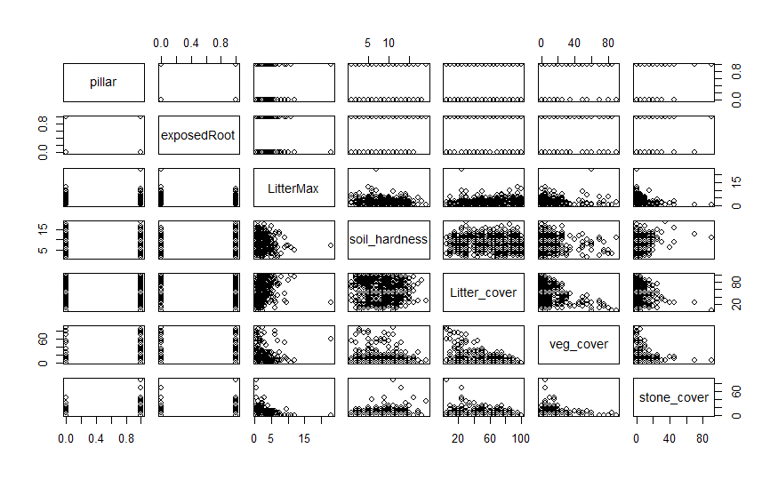

```r
plot(P1_2024[, 7:13])
```

– Spatial distribution

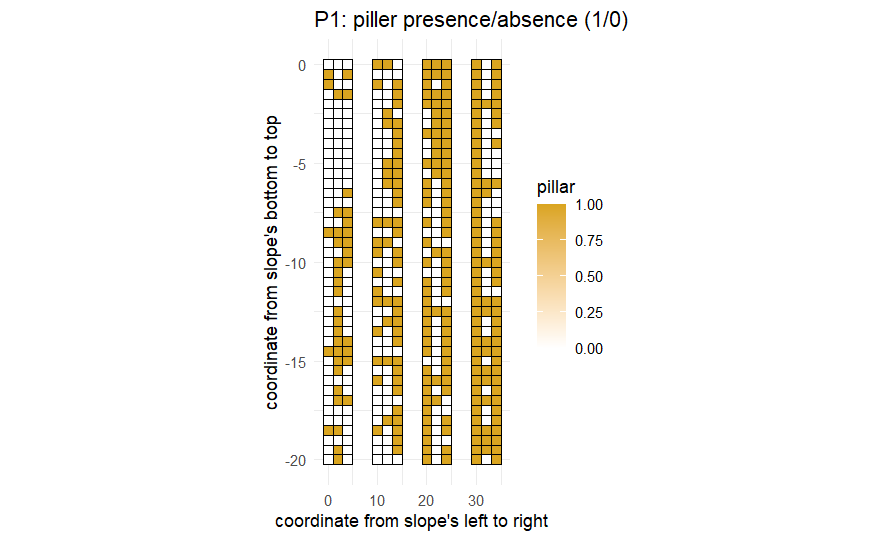

```r
ggplot(P1_2024, aes(x = x, y = y, fill = pillar)) +
  geom_tile(color = "black", linewidth = 0.5) +
  scale_fill_gradient(low = "white", high = "goldenrod", limits = c(0, 1)) +
  labs(title = "P1: piller presence/absence (1/0)",
       x = "coordinate from slope's left to right",
       y = "coordinate from slope's bottom to top") +
  coord_fixed(ratio = 4.0) +  # aspect ratio
  theme_minimal()
```

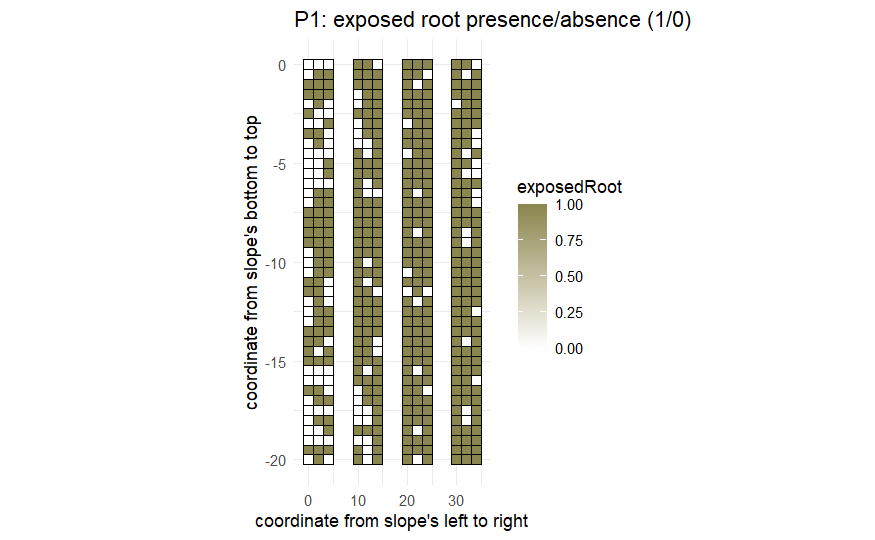

```r
ggplot(P1_2024, aes(x = x, y = y, fill = exposedRoot)) +
  geom_tile(color = "black", linewidth = 0.5) +
  scale_fill_gradient(low = "white", high = "khaki4", limits = c(0, 1)) +
  labs(title = "P1: exposed root presence/absence (1/0)",
       x = "coordinate from slope's left to right",
       y = "coordinate from slope's bottom to top") +
  coord_fixed(ratio = 4.0) +
  theme_minimal()
```

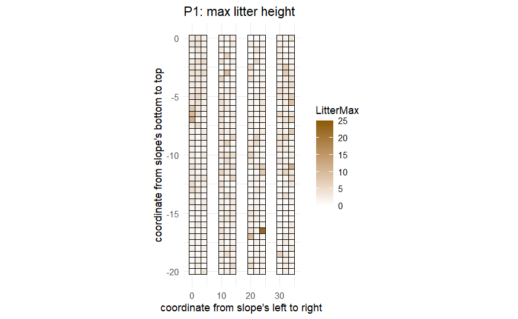

```r
ggplot(P1_2024, aes(x = x, y = y, fill = LitterMax)) +
  geom_tile(color = "black", linewidth = 0.5) +
  scale_fill_gradient(low = "white", high = "orange4", limits = c(0, 25)) +
  labs(title = "P1: max litter height",
       x = "coordinate from slope's left to right",
       y = "coordinate from slope's bottom to top") +
  coord_fixed(ratio = 4.0) +
  theme_minimal()
```

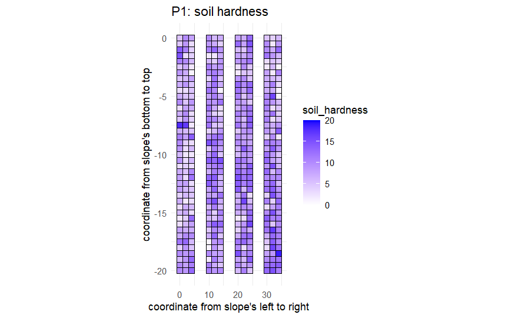

```r
ggplot(P1_2024, aes(x = x, y = y, fill = soil_hardness)) +
  geom_tile(color = "black", linewidth = 0.5) +
  scale_fill_gradient(low = "white", high = "blue", limits = c(0, 20)) +
  labs(title = "P1: soil hardness",
       x = "coordinate from slope's left to right",
       y = "coordinate from slope's bottom to top") +
  coord_fixed(ratio = 4.0) +
  theme_minimal()
```

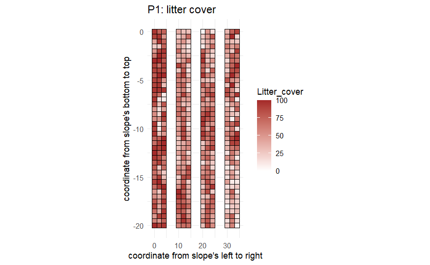

```r
ggplot(P1_2024, aes(x = x, y = y, fill = Litter_cover)) +
  geom_tile(color = "black", linewidth = 0.5) +
  scale_fill_gradient(low = "white", high = "brown", limits = c(0, 100)) +
  labs(title = "P1: litter cover",
       x = "coordinate from slope's left to right",
       y = "coordinate from slope's bottom to top") +
  coord_fixed(ratio = 4.0) +
  theme_minimal()
```

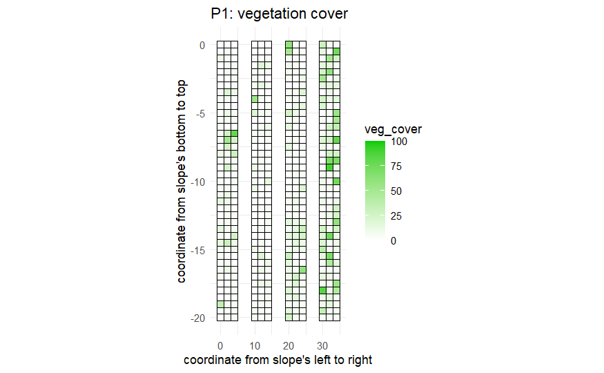

```r
ggplot(P1_2024, aes(x = x, y = y, fill = veg_cover)) +
  geom_tile(color = "black", linewidth = 0.5) +
  scale_fill_gradient(low = "white", high = "green3", limits = c(0, 100)) +
  labs(title = "P1: vegetation cover",
       x = "coordinate from slope's left to right",
       y = "coordinate from slope's bottom to top") +
  coord_fixed(ratio = 4.0) +
  theme_minimal()
```

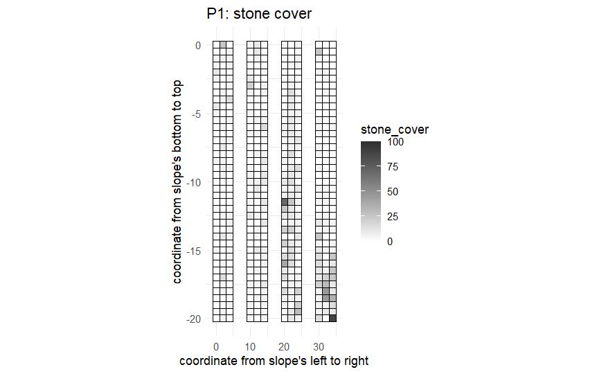

```r
ggplot(P1_2024, aes(x = x, y = y, fill = stone_cover)) +
  geom_tile(color = "black", linewidth = 0.5) +
  scale_fill_gradient(low = "white", high = "gray19", limits = c(0, 100)) +
  labs(title = "P1: stone cover",
       x = "coordinate from slope's left to right",
       y = "coordinate from slope's bottom to top") +
  coord_fixed(ratio = 4.0) +
  theme_minimal()
```

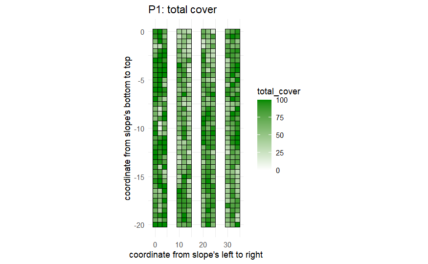

```r
ggplot(P1_2024, aes(x = x, y = y, fill = total_cover)) +
  geom_tile(color = "black", linewidth = 0.5) +
  scale_fill_gradient(low = "white", high = "green4", limits = c(0, 100)) +
  labs(title = "P1: total cover",
       x = "coordinate from slope's left to right",
       y = "coordinate from slope's bottom to top") +
  coord_fixed(ratio = 4.0) +
  theme_minimal()
```

### [2.2] Visualization of macro variables

– Correlation

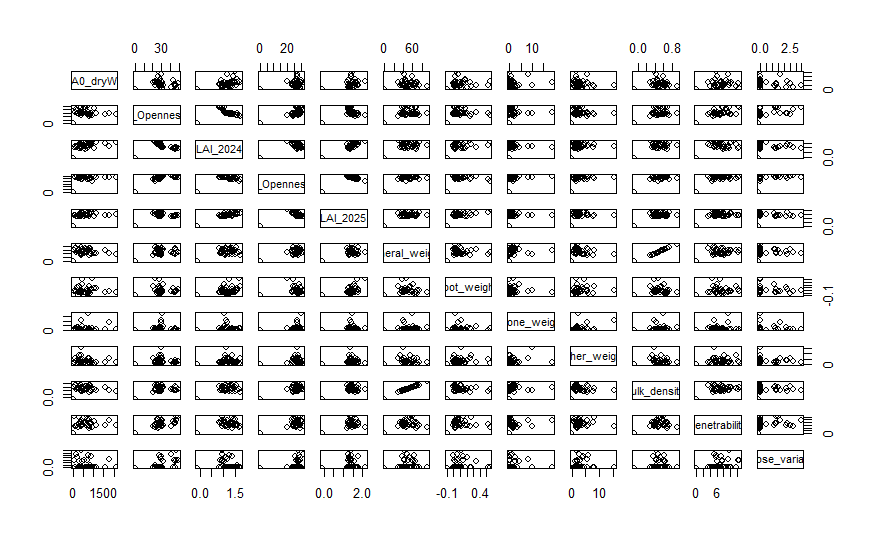

```r
plot(P1_2024[, 15:26])
```

– Spatial distribution

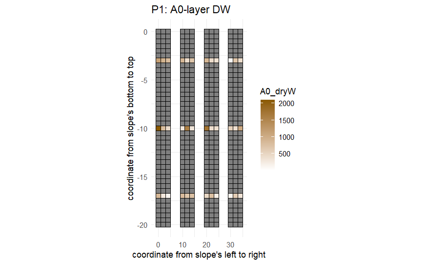

```r
ggplot(P1_2024, aes(x = x, y = y, fill = A0_dryW)) +
  geom_tile(color = "black", linewidth = 0.5) +
  scale_fill_gradient(low = "white", high = "orange4", limits = c(10, max(P1_2024$A0_dryW))) +
  labs(title = "P1: A0-layer DW",
       x = "coordinate from slope's left to right",
       y = "coordinate from slope's bottom to top") +
  coord_fixed(ratio = 4.0) +
  theme_minimal()
```

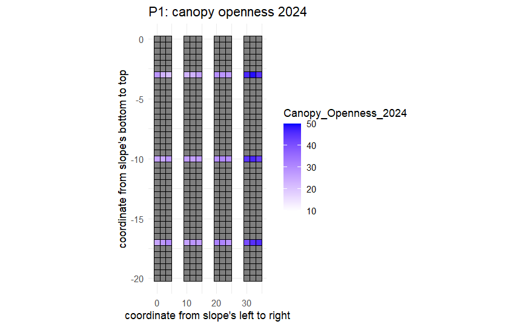

```r
ggplot(P1_2024, aes(x = x, y = y, fill = Canopy_Openness_2024)) +
  geom_tile(color = "black", linewidth = 0.5) +
  scale_fill_gradient(low = "white", high = "blue", limits = c(10, 50)) +
  labs(title = "P1: canopy openness 2024",
       x = "coordinate from slope's left to right",
       y = "coordinate from slope's bottom to top") +
  coord_fixed(ratio = 4.0) +
  theme_minimal()
```

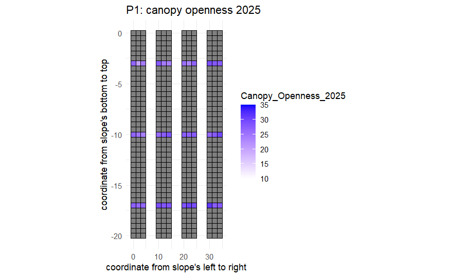

```r
ggplot(P1_2024, aes(x = x, y = y, fill = Canopy_Openness_2025)) +
  geom_tile(color = "black", linewidth = 0.5) +
  scale_fill_gradient(low = "white", high = "blue", limits = c(10, 35)) +
  labs(title = "P1: canopy openness 2025",
       x = "coordinate from slope's left to right",
       y = "coordinate from slope's bottom to top") +
  coord_fixed(ratio = 4.0) +
  theme_minimal()
```

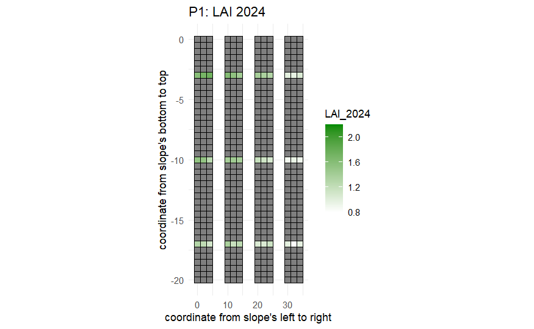

```r
ggplot(P1_2024, aes(x = x, y = y, fill = LAI_2024)) +
  geom_tile(color = "black", linewidth = 0.5) +
  scale_fill_gradient(low = "white", high = "green4", limits = c(0.8, 2.2)) +
  labs(title = "P1: LAI 2024",
       x = "coordinate from slope's left to right",
       y = "coordinate from slope's bottom to top") +
  coord_fixed(ratio = 4.0) +
  theme_minimal()
```

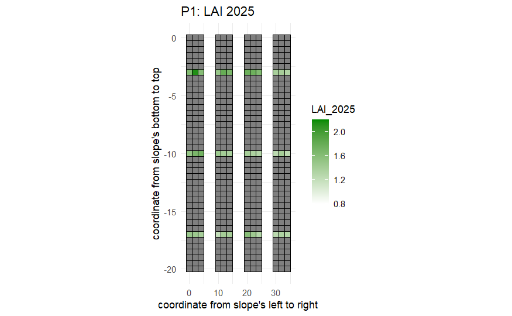

```r
ggplot(P1_2024, aes(x = x, y = y, fill = LAI_2025)) +
  geom_tile(color = "black", linewidth = 0.5) +
  scale_fill_gradient(low = "white", high = "green4", limits = c(0.8, 2.2)) +
  labs(title = "P1: LAI 2025",
       x = "coordinate from slope's left to right",
       y = "coordinate from slope's bottom to top") +
  coord_fixed(ratio = 4.0) +
  theme_minimal()
```

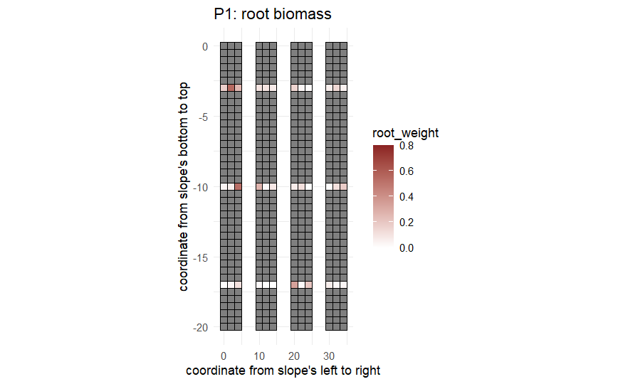

```r
ggplot(P1_2024, aes(x = x, y = y, fill = root_weight)) +
  geom_tile(color = "black", linewidth = 0.5) +
  scale_fill_gradient(low = "white", high = "brown4", limits = c(0.0, 0.8)) +
  labs(title = "P1: root biomass",
       x = "coordinate from slope's left to right",
       y = "coordinate from slope's bottom to top") +
  coord_fixed(ratio = 4.0) +
  theme_minimal()
```

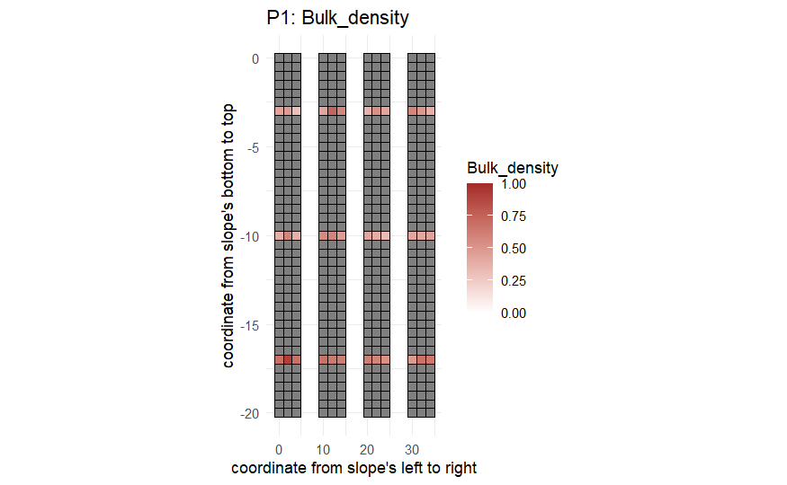

```r
ggplot(P1_2024, aes(x = x, y = y, fill = Bulk_density)) +
  geom_tile(color = "black", linewidth = 0.5) +
  scale_fill_gradient(low = "white", high = "brown", limits = c(0.0, 1.0)) +
  labs(title = "P1: Bulk_density",
       x = "coordinate from slope's left to right",
       y = "coordinate from slope's bottom to top") +
  coord_fixed(ratio = 4.0) +
  theme_minimal()
```

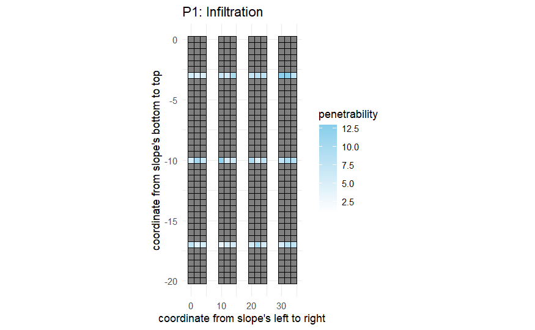

```r
ggplot(P1_2024, aes(x = x, y = y, fill = penetrability)) +
  geom_tile(color = "black", linewidth = 0.5) +
  scale_fill_gradient(low = "white", high = "skyblue", limits = c(1, 13)) +
  labs(title = "P1: Infiltration",
       x = "coordinate from slope's left to right",
       y = "coordinate from slope's bottom to top") +
  coord_fixed(ratio = 4.0) +
  theme_minimal()
```

### For Fig 1

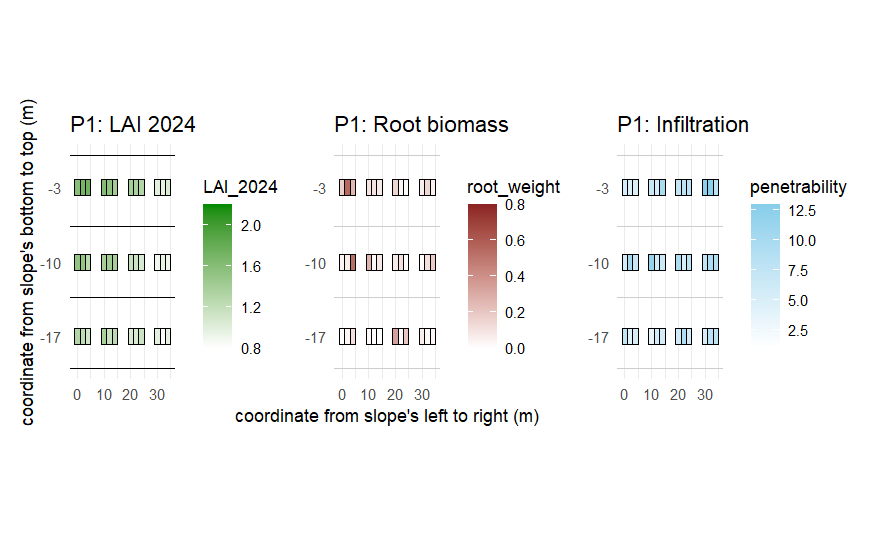

```r
P1_2024_sub <- subset(P1_2024, LAI_2024 > 0)
y_grid <- seq(0, -20, length.out = 4)

p1 <- ggplot(P1_2024_sub,
             aes(x = x, y = y, fill = LAI_2024)) +

  # background horizontal grid lines
  geom_hline(
    yintercept = y_grid,
    color = "black",
    linewidth = 0.4
  ) +

  geom_tile(
    height = 0.5 * resolution(P1_2024_sub$y),
    color = "black",
    linewidth = 0.5
  ) +

  scale_fill_gradient(
    low = "white",
    high = "green4",
    limits = c(0.8, 2.2)
  ) +

  scale_y_continuous(
    breaks = c(-3, -10, -17),
    limits = c(-20, 0)
  ) +

  labs(
    title = "P1: LAI 2024",
    x = "coordinate from slope's left to right (m)",
    y = "coordinate from slope's bottom to top (m)"
  ) +

  coord_fixed(ratio = 4.0) +

  theme_minimal() +
  theme(
    panel.grid.major.y = element_blank(),
    panel.grid.minor.y = element_blank()
  )

p2 <- ggplot(P1_2024_sub,
             aes(x = x, y = y, fill = root_weight)) +

  # background horizontal grid lines
  geom_hline(
    yintercept = y_grid,
    color = "grey80",
    linewidth = 0.4
  ) +

  geom_tile(
    height = 0.5 * resolution(P1_2024_sub$y),
    color = "black",
    linewidth = 0.5
  ) +

  scale_fill_gradient(
    low = "white",
    high = "brown4",
    limits = c(0, 0.8)
  ) +

  scale_y_continuous(
    breaks = c(-3, -10, -17),
    limits = c(-20, 0)
  ) +

  labs(
    title = "P1: Root biomass",
    x = "coordinate from slope's left to right (m)",
    y = "coordinate from slope's bottom to top (m)"
  ) +

  coord_fixed(ratio = 4.0) +

  theme_minimal() +
  theme(
    panel.grid.major.y = element_blank(),
    panel.grid.minor.y = element_blank()
  )

p3 <- ggplot(P1_2024_sub,
             aes(x = x, y = y, fill = penetrability)) +

  geom_hline(
    yintercept = y_grid,
    color = "grey80",
    linewidth = 0.4
  ) +

  geom_tile(
    height = 0.5 * resolution(P1_2024_sub$y),
    color = "black",
    linewidth = 0.5
  ) +
  scale_fill_gradient(
    low = "white",
    high = "skyblue",
    limits = c(1, 13)
  ) +
  scale_y_continuous(
    breaks = c(-3, -10, -17),
    limits = c(-20, 0)
  ) +
  labs(
    title = "P1: Infiltration",
    x = "coordinate from slope's left to right (m)",
    y = "coordinate from slope's bottom to top (m)"
  ) +
  coord_fixed(ratio = 4.0) +
  theme_minimal() +
  theme(
    panel.grid.major.y = element_blank(),
    panel.grid.minor.y = element_blank()
  )

p1 <- p1 + labs(x = NULL)
p2 <- p2 + labs(y = NULL)
p3 <- p3 + labs(x = NULL, y = NULL)
p1 + p2 + p3
```

### For Fig 2

[figure not shown]

```r
p21 <- ggplot(P1_2024, aes(x = x, y = y, fill = pillar)) +
  geom_tile(color = "black", linewidth = 0.5) +
  scale_fill_gradient(low = "white", high = "goldenrod", limits = c(0, 1)) +
  labs(title = "P1: piller presence/absence (1/0)",
       x = "coordinate from slope's left to right",
       y = "coordinate from slope's bottom to top") +
  coord_fixed(ratio = 4.0) +  # aspect ratio
  theme_minimal()

p22 <- ggplot(P1_2024, aes(x = x, y = y, fill = exposedRoot)) +
  geom_tile(color = "black", linewidth = 0.5) +
  scale_fill_gradient(low = "white", high = "khaki4", limits = c(0, 1)) +
  labs(title = "P1: exposed root presence/absence (1/0)",
       x = "coordinate from slope's left to right",
       y = "coordinate from slope's bottom to top") +
  coord_fixed(ratio = 4.0) +
  theme_minimal()

p23 <- ggplot(P1_2024, aes(x = x, y = y, fill = LitterMax)) +
  geom_tile(color = "black", linewidth = 0.5) +
  scale_fill_gradient(low = "white", high = "orange4", limits = c(0, 25)) +
  labs(title = "P1: max litter height",
       x = "coordinate from slope's left to right",
       y = "coordinate from slope's bottom to top") +
  coord_fixed(ratio = 4.0) +
  theme_minimal()

p24 <- ggplot(P1_2024, aes(x = x, y = y, fill = soil_hardness)) +
  geom_tile(color = "black", linewidth = 0.5) +
  scale_fill_gradient(low = "white", high = "blue", limits = c(0, 20)) +
  labs(title = "P1: soil hardness",
       x = "coordinate from slope's left to right",
       y = "coordinate from slope's bottom to top") +
  coord_fixed(ratio = 4.0) +
  theme_minimal()

p25 <- ggplot(P1_2024, aes(x = x, y = y, fill = Litter_cover)) +
  geom_tile(color = "black", linewidth = 0.5) +
  scale_fill_gradient(low = "white", high = "brown", limits = c(0, 100)) +
  labs(title = "P1: litter cover",
       x = "coordinate from slope's left to right",
       y = "coordinate from slope's bottom to top") +
  coord_fixed(ratio = 4.0) +
  theme_minimal()

p26 <- ggplot(P1_2024, aes(x = x, y = y, fill = veg_cover)) +
  geom_tile(color = "black", linewidth = 0.5) +
  scale_fill_gradient(low = "white", high = "green3", limits = c(0, 100)) +
  labs(title = "P1: vegetation cover",
       x = "coordinate from slope's left to right",
       y = "coordinate from slope's bottom to top") +
  coord_fixed(ratio = 4.0) +
  theme_minimal()

p27 <- ggplot(P1_2024, aes(x = x, y = y, fill = stone_cover)) +
  geom_tile(color = "black", linewidth = 0.5) +
  scale_fill_gradient(low = "white", high = "gray19", limits = c(0, 100)) +
  labs(title = "P1: stone cover",
       x = "coordinate from slope's left to right",
       y = "coordinate from slope's bottom to top") +
  coord_fixed(ratio = 4.0) +
  theme_minimal()

p28 <- ggplot(P1_2024, aes(x = x, y = y, fill = total_cover)) +
  geom_tile(color = "black", linewidth = 0.5) +
  scale_fill_gradient(low = "white", high = "green4", limits = c(0, 100)) +
  labs(title = "P1: total cover",
       x = "coordinate from slope's left to right",
       y = "coordinate from slope's bottom to top") +
  coord_fixed(ratio = 4.0) +
  theme_minimal()

p21 <- p21 + labs(x = NULL)
p22 <- p22 + labs(x = NULL, y = NULL)
p23 <- p23 + labs(x = NULL, y = NULL)
p24 <- p24 + labs(x = NULL, y = NULL)

p26 <- p26 + labs(y = NULL)
p27 <- p27 + labs(y = NULL)
p28 <- p28 + labs(y = NULL)


row1 <- p21 | p22 | p23 | p24
row2 <- p25 | p26 | p27 | p28

row1 / row2
```

## [3] Spatial index calculation by epiphy

https://chgigot.github.io/epiphy/articles/epiphy.html

### [3.1] Trial of SADIE

For U01

```r
u01_P1_2024 <- subset(P1_2024, UnitID == "U1")
```

```r
#Explicit mapping
(LitterMax_u01_P1_2024 <- epiphy::count(u01_P1_2024, mapping(x = x, y = y, i = LitterMax)))
```

```
# A mapped object: count class
# dim: 2 space, 0 time, 1 obs
```

|  | . | . | . | . | [x] | [y] | . | . | [i] | . | . | . | . | . | . | . | . | . | . | . | . | . | . | . | . | . |
| --- | --- | --- | --- | --- | --- | --- | --- | --- | --- | --- | --- | --- | --- | --- | --- | --- | --- | --- | --- | --- | --- | --- | --- | --- | --- | --- |
|  | PlotID | UnitID | LineID | SpotID | x | y | pillar | exposedRoot | LitterMax | soil_hardness | Litter_cover | veg_cover | stone_cover | total_cover | A0_dryW | Canopy_Openness_2024 | LAI_2024 | Canopy_Openness_2025 | LAI_2025 | mineral_weight | root_weight | stone_weight | other_weight | Bulk_density | penetrability | expose_variance |
| 1 | P1 | U1 | L1 | S01 | 0 | 0 | 0 | 0 | 3 | 5 | 95 | 0 | 0 | 95 | -0.1 | -0.1 | -0.1 | -0.1 | -0.1 | -0.1 | -0.1 | -0.1 | -0.1 | -0.1 | -0.1 | -0.1 |
| 2 | P1 | U1 | L1 | S02 | 0 | -0.5 | 1 | 0 | 3.5 | 5 | 90 | 0 | 0 | 90 | -0.1 | -0.1 | -0.1 | -0.1 | -0.1 | -0.1 | -0.1 | -0.1 | -0.1 | -0.1 | -0.1 | -0.1 |
| 3 | P1 | U1 | L1 | S03 | 0 | -1 | 1 | 1 | 2 | 14 | 45 | 10 | 5 | 60 | -0.1 | -0.1 | -0.1 | -0.1 | -0.1 | -0.1 | -0.1 | -0.1 | -0.1 | -0.1 | -0.1 | -0.1 |
| 4 | P1 | U1 | L1 | S04 | 0 | -1.5 | 0 | 1 | 1 | 15 | 25 | 0 | 5 | 30 | -0.1 | -0.1 | -0.1 | -0.1 | -0.1 | -0.1 | -0.1 | -0.1 | -0.1 | -0.1 | -0.1 | -0.1 |
| 5 | P1 | U1 | L1 | S05 | 0 | -2 | 0 | 0 | 2.5 | 11 | 50 | 0 | 10 | 60 | -0.1 | -0.1 | -0.1 | -0.1 | -0.1 | -0.1 | -0.1 | -0.1 | -0.1 | -0.1 | -0.1 | -0.1 |
| 6 | P1 | U1 | L1 | S06 | 0 | -2.5 | 0 | 1 | 4 | 5 | 65 | 0 | 5 | 70 | -0.1 | -0.1 | -0.1 | -0.1 | -0.1 | -0.1 | -0.1 | -0.1 | -0.1 | -0.1 | -0.1 | -0.1 |

```
# ... with 117 more records (rows)
```

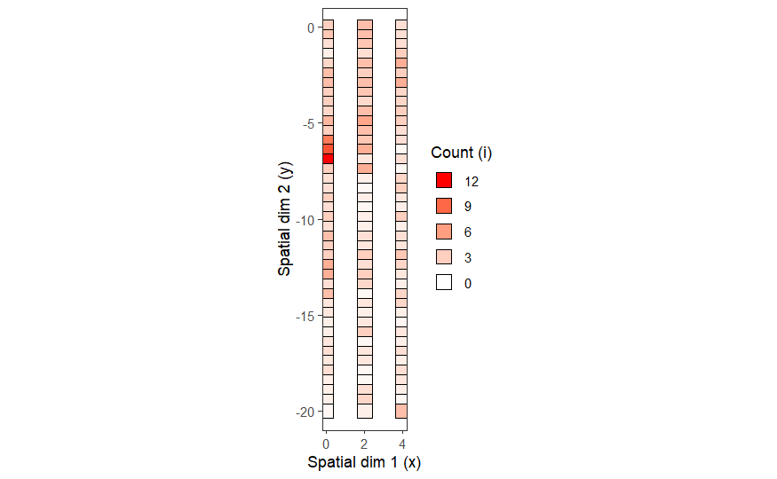

```r
plot(LitterMax_u01_P1_2024, tile = FALSE, size = 5)
```

```r
#Computation of SADIE
set.seed(1234)
for(i in 1:1) capture.output(sadie_LitterMax_u01_P1_2024 <- sadie(LitterMax_u01_P1_2024, index = "all", threads = 2))
```

Showing the results

```r
#The aggregation index
sadie_LitterMax_u01_P1_2024$summary_idx
```

|  | overall | inflow | outflow |
| --- | --- | --- | --- |
| Perry's index | 3.303126 | -3.440085 | 3.258888 |
| Li-Madden-Xu's index | 3.564383 | -3.820952 | 3.386114 |

```r
sadie_LitterMax_u01_P1_2024$info_clust$idx_LMX
```

```
  [1]   0.8099268   0.5422328  -0.8562010  -0.7539493   0.6204649   5.4084424
  [7]   6.7746765   6.6695911   5.3211444   5.5461992   4.2622363   5.7305104
 [13]   3.7766312   3.5953758   2.8713224   0.2895724   0.0000000  -0.3578196
 [19]   6.1757297   2.3146574   7.8069226  -0.6057208   0.5118431   4.2975441
 [25]   4.3976794   2.9681411   1.4544367   0.3576517  -0.8984205  -0.3812332
 [31]  -1.2058459  -1.0104763  -1.9044508  -5.4839637  -6.6948578  -3.4854892
 [37]  -5.9198026  -3.2253248  -5.5916736  -4.5022711  -5.7717784   1.5787754
 [43]   7.1607977   3.4776693  -0.3580599   7.3225670   7.4287301   6.6785138
 [49]   6.5636705  -0.3314722   7.9190413   5.3264887   6.8364278   5.0356432
 [55]   0.5795350  -0.2924250   0.4554059  -0.2420511  -0.6472885  -1.1339178
 [61]  -2.8314993  -3.0464885  -2.9533493  -4.7408865  -4.0137754   6.0516321
 [67]  -4.6508789   4.4316564   4.0575654  -4.0493264  -4.8039914  -4.4946201
 [73]  -5.6797831   0.4069580  -3.3444346  -5.3417074  -6.6801751  -5.6388684
 [79]  -5.3308789  -6.6066093   0.4580444  -6.2580506  -1.1876235  -1.6456298
 [85]  -0.3812503   0.8112739   1.0368553   4.7897637   3.1112505   2.9749790
 [91]   2.5293854   2.1711706   1.0571917  -3.0095496  -0.8706845  -2.0271484
 [97]  -2.0928275  -2.2951415   0.7846079  -4.1227475  -0.3618374  -4.7657335
[103]   0.3974319  -4.4624387  -6.3309433  -7.1395228   0.4149891   0.0000000
[109]  -0.3437991  -5.6171530   0.9168722   0.6603042  -7.0462362  -6.2261680
[115]  -7.5547285  -6.4869764 -12.9953992  -7.2852242  -9.8127544  -6.9757072
[121]  -8.0337280  -0.9920514   0.3081578
```

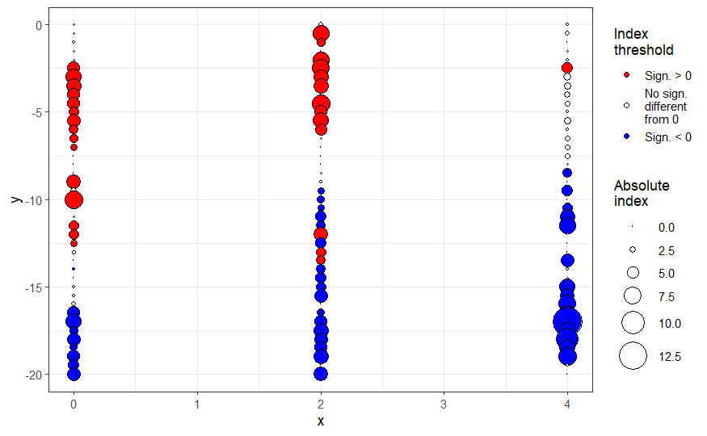

```r
plot(sadie_LitterMax_u01_P1_2024, index = "Li-Madden-Xu")
```

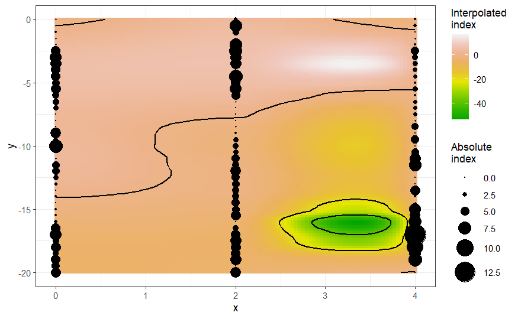

```r
plot(sadie_LitterMax_u01_P1_2024, index = "Li-Madden-Xu", isoclines = TRUE)
```

### [3.2] Trial of regression again macro variables

– Extracting the data with macro variables

```r
macro_P1_2024 <- subset(P1_2024, P1_2024$A0_dryW > 0)
```

– Averaging at each section level

```r
mean_LitterMax_u01 <- list()
for(j in 1:3) {
  mean_LitterMax_u01[[j]] <- numeric(3)
  sub_sadie_LitterMax_u01 <- subset(sadie_LitterMax_u01_P1_2024$info_clust, sadie_LitterMax_u01_P1_2024$info_clust$x == (2*(j - 1)))
  mean_LitterMax_u01[[j]][1] <- mean(sub_sadie_LitterMax_u01$idx_LMX[1:14])
  mean_LitterMax_u01[[j]][2] <- mean(sub_sadie_LitterMax_u01$idx_LMX[15:28])
  mean_LitterMax_u01[[j]][3] <- mean(sub_sadie_LitterMax_u01$idx_LMX[29:41])
}
mean_LitterMax_u01
```

```
[[1]]
[1]  3.389092  2.320140 -3.544276

[[2]]
[1]  4.6584520 -0.6825929 -4.4125725

[[3]]
[1]  0.6685703 -2.5667940 -5.5018184
```

– Correlation with macro variables

```r
macro_P1_2024[1:9, 15:26]
```

|  | A0_dryW | Canopy_Openness_2024 | LAI_2024 | Canopy_Openness_2025 | LAI_2025 | mineral_weight | root_weight | stone_weight | other_weight | Bulk_density | penetrability | expose_variance |
| --- | --- | --- | --- | --- | --- | --- | --- | --- | --- | --- | --- | --- |
| 7 | 1160.75 | 28.19 | 1.59 | 26.76 | 1.63 | 43.98 | 0.170 | 0.24 | 2.01 | 0.4398 | 5.623606 | 0 |
| 21 | 2099.75 | 25.89 | 1.52 | 26.79 | 1.51 | 37.74 | 0.040 | 0.56 | 1.71 | 0.3774 | 5.678285 | 0 |
| 35 | 874.50 | 25.29 | 1.31 | 27.21 | 1.47 | 69.25 | 0.006 | 0.00 | 1.16 | 0.6925 | 7.440127 | 0 |
| 48 | 927.75 | 23.13 | 1.70 | 20.11 | 2.14 | 47.30 | 0.550 | 1.85 | 1.40 | 0.4730 | 4.654823 | 0 |
| 62 | 793.00 | 24.98 | 1.52 | 25.13 | 1.67 | 57.86 | 0.060 | 0.89 | 0.75 | 0.5786 | 10.240214 | 0 |
| 76 | 279.00 | 27.87 | 1.23 | 26.38 | 1.45 | 91.84 | 0.030 | 3.22 | 1.97 | 0.9184 | 4.146808 | 0 |
| 89 | 800.00 | 20.96 | 1.74 | 24.36 | 1.61 | 29.65 | 0.260 | 1.99 | 5.69 | 0.2965 | 5.000530 | 0 |
| 103 | 439.75 | 27.94 | 1.26 | 23.99 | 1.72 | 37.35 | 0.530 | 0.00 | 4.42 | 0.3735 | 6.875920 | 0 |
| 117 | 136.50 | 30.48 | 1.10 | 26.60 | 1.38 | 69.25 | 0.110 | 2.13 | 5.52 | 0.6925 | 5.244545 | 0 |

```r
macro_P1_2024_sub_u01 <- data.frame(macro_P1_2024[1:9, 15:26], mean_LitterMax_u01 = unlist(mean_LitterMax_u01))
```

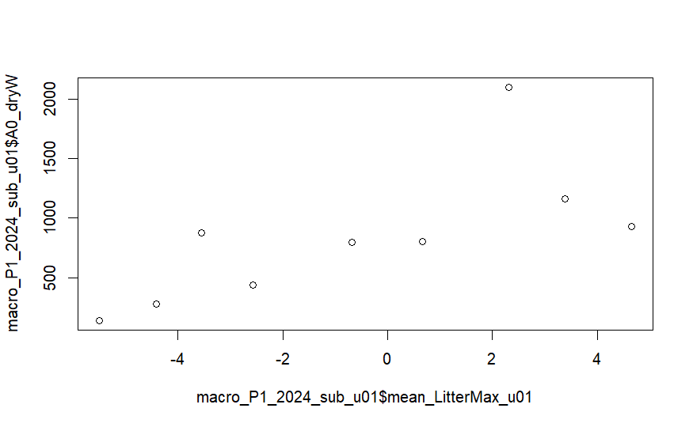

```r
plot(macro_P1_2024_sub_u01$A0_dryW ~ macro_P1_2024_sub_u01$mean_LitterMax_u01)
```

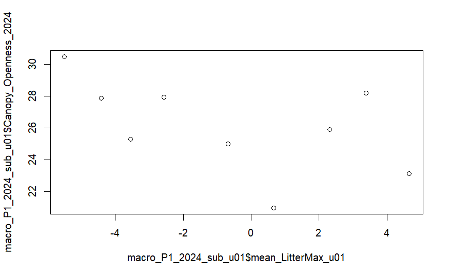

```r
plot(macro_P1_2024_sub_u01$Canopy_Openness_2024 ~ macro_P1_2024_sub_u01$mean_LitterMax_u01)
```

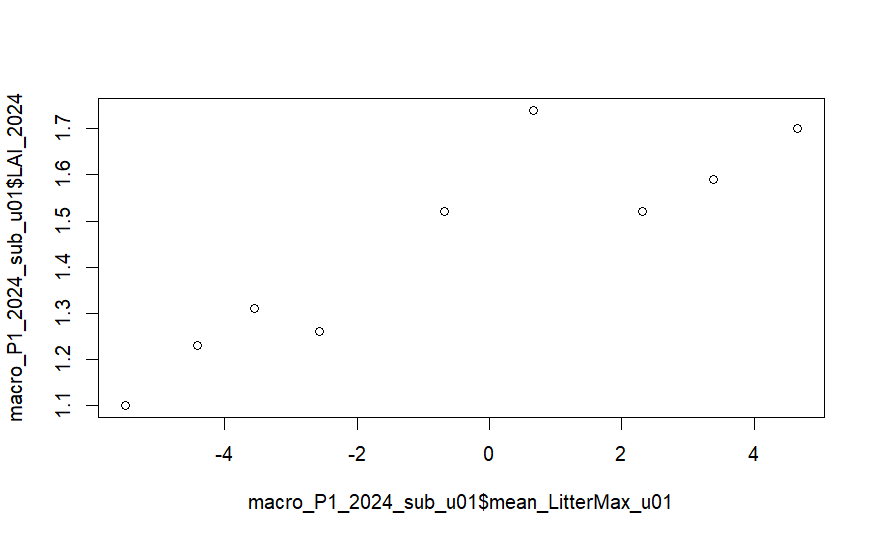

```r
plot(macro_P1_2024_sub_u01$LAI_2024 ~ macro_P1_2024_sub_u01$mean_LitterMax_u01)
```

### [3.3] SADIE

```r
u_P1_2024 <- list()
u_P1_2024[[1]] <- subset(P1_2024, UnitID == "U1")
u_P1_2024[[2]] <- subset(P1_2024, UnitID == "U2")
u_P1_2024[[3]] <- subset(P1_2024, UnitID == "U3")
u_P1_2024[[4]] <- subset(P1_2024, UnitID == "U4")
```

```r
set.seed(1234)
#Data extraction
pillar_u_P1_2024 <- list()
exposedRoot_u_P1_2024 <- list()
LitterMax_u_P1_2024 <- list()
soil_hardness_u_P1_2024 <- list()
Litter_cover_u_P1_2024 <- list()
veg_cover_u_P1_2024 <- list()
stone_cover_u_P1_2024 <- list()
total_cover_u_P1_2024 <- list()

sadie_pillar_u_P1_2024 <- list()
sadie_exposedRoot_u_P1_2024 <- list()
sadie_LitterMax_u_P1_2024 <- list()
sadie_soil_hardness_u_P1_2024 <- list()
sadie_Litter_cover_u_P1_2024 <- list()
sadie_veg_cover_u_P1_2024 <- list()
sadie_stone_cover_u_P1_2024 <- list()
sadie_total_cover_u_P1_2024 <- list()

for(j in 1:4){
  pillar_u_P1_2024[[j]] <- epiphy::count(u_P1_2024[[j]], mapping(x = x, y = y, i = pillar))
  exposedRoot_u_P1_2024[[j]] <- epiphy::count(u_P1_2024[[j]], mapping(x = x, y = y, i = exposedRoot))
  LitterMax_u_P1_2024[[j]] <- epiphy::count(u_P1_2024[[j]], mapping(x = x, y = y, i = LitterMax))
  soil_hardness_u_P1_2024[[j]] <- epiphy::count(u_P1_2024[[j]], mapping(x = x, y = y, i = soil_hardness))
  Litter_cover_u_P1_2024[[j]] <- epiphy::count(u_P1_2024[[j]], mapping(x = x, y = y, i = Litter_cover))
  veg_cover_u_P1_2024[[j]] <- epiphy::count(u_P1_2024[[j]], mapping(x = x, y = y, i = veg_cover))
  stone_cover_u_P1_2024[[j]] <- epiphy::count(u_P1_2024[[j]], mapping(x = x, y = y, i = stone_cover))
  total_cover_u_P1_2024[[j]] <- epiphy::count(u_P1_2024[[j]], mapping(x = x, y = y, i = total_cover))
}
for(j in 1:4) {
  capture.output(sadie_pillar_u_P1_2024[[j]] <- sadie(pillar_u_P1_2024[[j]], index = "all", threads = 2))
  cat("+")
  capture.output(sadie_exposedRoot_u_P1_2024[[j]] <- sadie(exposedRoot_u_P1_2024[[j]], index = "all", threads = 2))
  capture.output(sadie_LitterMax_u_P1_2024[[j]] <- sadie(LitterMax_u_P1_2024[[j]], index = "all", threads = 2))
  cat("+")
  capture.output(sadie_soil_hardness_u_P1_2024[[j]] <- sadie(soil_hardness_u_P1_2024[[j]], index = "all", threads = 2))
  cat("+")
  capture.output(sadie_Litter_cover_u_P1_2024[[j]] <- sadie(Litter_cover_u_P1_2024[[j]], index = "all", threads = 2))
  cat("+")
  capture.output(sadie_veg_cover_u_P1_2024[[j]] <- sadie(veg_cover_u_P1_2024[[j]], index = "all", threads = 2))
  cat("+")
  capture.output(sadie_stone_cover_u_P1_2024[[j]] <- sadie(stone_cover_u_P1_2024[[j]], index = "all", threads = 2))
  cat("+")
  capture.output(sadie_total_cover_u_P1_2024[[j]] <- sadie(total_cover_u_P1_2024[[j]], index = "all", threads = 2))
  cat("+")
}
```

```
++++++++++++++++++++++++++++
```

## [4] Spatial correlation by Moran’s I

### [4.1] Trial of Moran’s I calculation

– Define the neighbors by the distance <= 2*sqrt(2) and its visualization

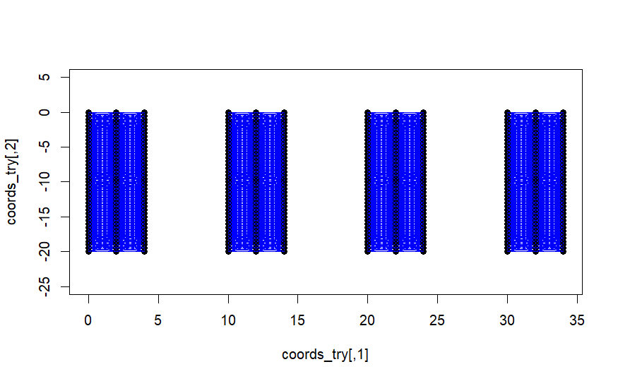

```r
max_dist <- 2.0*sqrt(2) #the diagonal of 2m x 2m square
coords_try <- cbind(P1_2024$x, P1_2024$y) #extract coordinates
nb_try <- dnearneigh(coords_try, 0, max_dist) #define the neighborhood
plot(coords_try, asp = 0.5, pch = 19)
plot(nb_try, coords_try, add = TRUE, col = "blue")
```

```r
lw_try <- nb2listw(nb_try, style="W") #wighted-spatial matrix
```

– Global and Local Moran’s I

```r
moran.test(P1_2024$LitterMax, lw_try)
```

```
    Moran I test under randomisation

data:  P1_2024$LitterMax
weights: lw_try

Moran I statistic standard deviate = 5.7392, p-value = 4.758e-09
alternative hypothesis: greater
sample estimates:
Moran I statistic       Expectation          Variance
     0.0757369647     -0.0020366599      0.0001836409
```

```r
local_try <- as.data.frame(localmoran(P1_2024$LitterMax, lw_try))
moran.test(P1_2024$LitterMax, lw_try)$statistic
```

```
Moran I statistic standard deviate
                          5.739151
```

```r
result_try <- data.frame(
  P1_2024[, c("LitterMax","x","y")],
  Ii = local_try$Ii
)
print(result_try)
```

| LitterMax | x | y | Ii |
| --- | --- | --- | --- |
| 3.0 | 0 | 0.0 | 0.1052373583 |
| 3.5 | 0 | -0.5 | 0.2047899391 |
| 2.0 | 0 | -1.0 | -0.0965839430 |
| 1.0 | 0 | -1.5 | -0.3560587184 |
| 2.5 | 0 | -2.0 | 0.0179111984 |
| 4.0 | 0 | -2.5 | 0.3179659440 |
| 4.0 | 0 | -3.0 | 0.3530776969 |
| 3.0 | 0 | -3.5 | 0.1828617650 |
| 3.0 | 0 | -4.0 | 0.2652563867 |
| 2.5 | 0 | -4.5 | 0.0562570021 |

[output cut: 482 more lines]

### [4.2] Moran’s I calculation on all micro variables

– Define the neighbors by the distance <= 2*sqrt(2) and its visualization

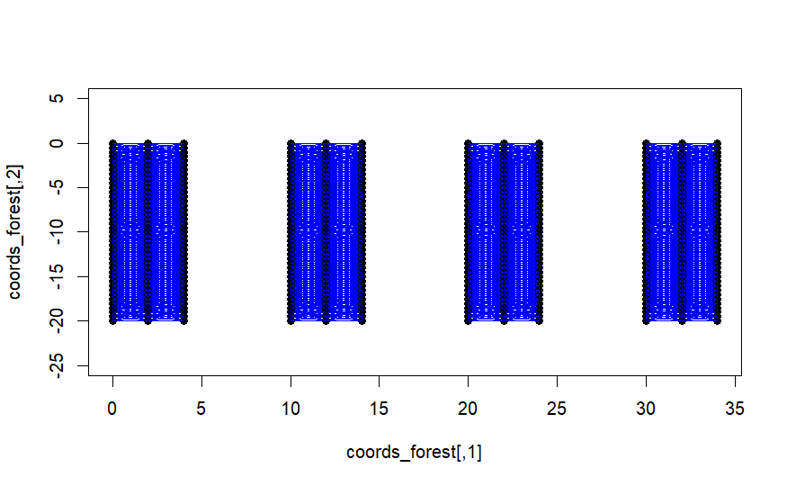

```r
max_dist <- 2.0*sqrt(2.0) #the diagonal of 2m x 2m square
coords_forest <- cbind(P1_2024$x, P1_2024$y) #extract coordinates
nb_forest <- dnearneigh(coords_forest, 0, max_dist) #define the neighborhood
plot(coords_forest, asp = 0.5, pch = 19)
plot(nb_forest, coords_forest, add = TRUE, col = "blue")
```

```r
lw_forest <- nb2listw(nb_forest, style = "W") #wighted-spatial matrix
```

– Calculate local moran

```r
P1_local_moran <- list()
for(i in 7:15) {
  P1_local_moran[[i]] <- as.data.frame(localmoran(P1_2024[, i], lw_forest))
}
```

– Summarize moran’s I

```r
P1_moran_forest <- data.frame(P1_2024[, 1:6])
for(i in 7:15) {
  P1_moran_forest[[colnames(P1_2024)[i]]] = P1_local_moran[[i]]$Ii
}
print(P1_moran_forest)
```

| PlotID | UnitID | LineID | SpotID | x | y | pillar | exposedRoot | LitterMax | soil_hardness | Litter_cover | veg_cover | stone_cover | total_cover | A0_dryW |
| --- | --- | --- | --- | --- | --- | --- | --- | --- | --- | --- | --- | --- | --- | --- |
| P1 | U1 | L1 | S01 | 0 | 0.0 | 0.503930131 | 0.29473684 | 0.1052373583 | -0.2224681783 | 0.4428826495 | 0.283718416 | -0.0654532928 | 0.1131852351 | 0.0538452156 |
| P1 | U1 | L1 | S02 | 0 | -0.5 | -0.688212928 | 0.79824561 | 0.2047899391 | -0.1635632906 | 0.6772913084 | 0.301781234 | -0.0007176896 | 0.2660056865 | -0.0527725384 |
| P1 | U1 | L1 | S03 | 0 | -1.0 | -0.732753938 | -0.34920635 | -0.0965839430 | -0.2075653925 | -0.3773025803 | -0.034871430 | -0.0066027444 | -0.2588929795 | -0.1105854068 |
| P1 | U1 | L1 | S04 | 0 | -1.5 | 0.745633188 | -0.34920635 | -0.3560587184 | -0.3724244849 | -1.0542165417 | 0.243077075 | -0.0074855027 | -1.2266896778 | -0.0900315790 |
| P1 | U1 | L1 | S05 | 0 | -2.0 | 0.790393013 | 0.91812865 | 0.0179111984 | -0.1384211217 | -0.2328370428 | 0.235550900 | -0.0806236563 | -0.3205297522 | -0.0740452685 |
| P1 | U1 | L1 | S06 | 0 | -2.5 | 0.809239255 | -0.38345865 | 0.3179659440 | 0.2168144259 | 0.2495825195 | 0.243790081 | -0.0127975390 | -0.0302542803 | -0.0673141904 |
| P1 | U1 | L1 | S07 | 0 | -3.0 | 0.809239255 | 1.27146814 | 0.3530776969 | -0.0386654825 | 1.2561010416 | 0.220973889 | 0.1185321057 | 0.7487854613 | -0.0005312045 |
| P1 | U1 | L1 | S08 | 0 | -3.5 | 0.922316709 | -0.52046784 | 0.1828617650 | 0.3169765832 | 0.9985969413 | 0.093715939 | 0.1371164893 | 0.6558998744 | -0.0673141904 |
| P1 | U1 | L1 | S09 | 0 | -4.0 | 1.148471616 | 1.95290859 | 0.2652563867 | 0.1592531361 | 1.2740017695 | 0.103919135 | 0.1371164893 | 0.8987252164 | -0.0673141904 |
| P1 | U1 | L1 | S10 | 0 | -4.5 | 1.148471616 | 2.18005540 | 0.0562570021 | 0.7243411140 | 0.9869573669 | 0.078411145 | -0.2288719732 | 1.0687029557 | -0.0673141904 |

[output cut: 482 more lines]

## [5] Regression to Macro variables

### [5.1] Averaging micro variables and their spatial indices (Moran’s I and LMX)

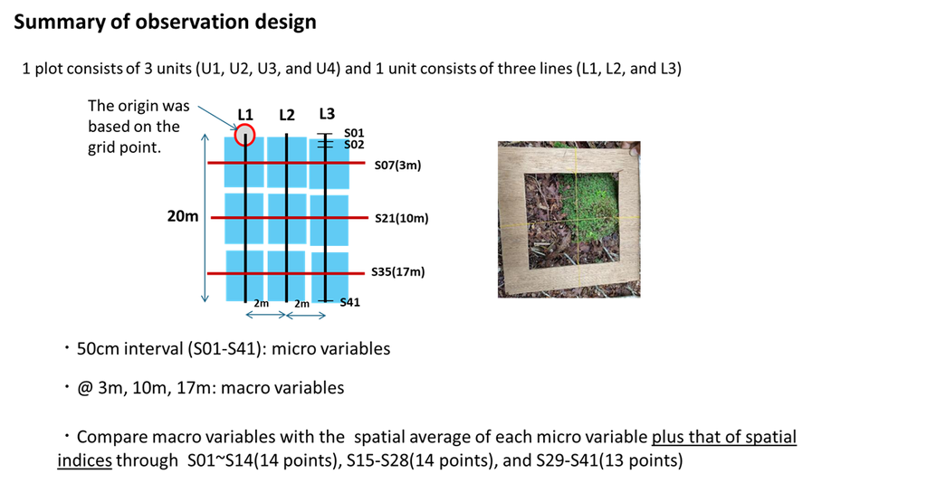

Sampling design

```r
micro_variables_u_P1_2024 <- list()
micro_variables_u_P1_2024[[1]] <- subset(P1_2024, P1_2024$UnitID == "U1")
micro_variables_u_P1_2024[[2]] <- subset(P1_2024, P1_2024$UnitID == "U2")
micro_variables_u_P1_2024[[3]] <- subset(P1_2024, P1_2024$UnitID == "U3")
micro_variables_u_P1_2024[[4]] <- subset(P1_2024, P1_2024$UnitID == "U4")

local_moran_u_P1_2024 <- list()
local_moran_u_P1_2024[[1]] <- subset(P1_moran_forest, P1_moran_forest$UnitID == "U1")
local_moran_u_P1_2024[[2]] <- subset(P1_moran_forest, P1_moran_forest$UnitID == "U2")
local_moran_u_P1_2024[[3]] <- subset(P1_moran_forest, P1_moran_forest$UnitID == "U3")
local_moran_u_P1_2024[[4]] <- subset(P1_moran_forest, P1_moran_forest$UnitID == "U4")

#mean of micro variables themselves
mean_pillar_u_P1_2024 <- list()
mean_exposedRoot_u_P1_2024 <- list()
mean_LitterMax_u_P1_2024 <- list()
mean_soil_hardness_u_P1_2024 <- list()
mean_Litter_cover_u_P1_2024 <- list()
mean_veg_cover_u_P1_2024 <- list()
mean_stone_cover_u_P1_2024 <- list()
mean_total_cover_u_P1_2024 <- list()
#mean of spatial index (LMX)
LMX_mean_pillar_u_P1_2024 <- list()
LMX_mean_exposedRoot_u_P1_2024 <- list()
LMX_mean_LitterMax_u_P1_2024 <- list()
LMX_mean_soil_hardness_u_P1_2024 <- list()
LMX_mean_Litter_cover_u_P1_2024 <- list()
LMX_mean_veg_cover_u_P1_2024 <- list()
LMX_mean_stone_cover_u_P1_2024 <- list()
LMX_mean_total_cover_u_P1_2024 <- list()
#mean of spatial autocorraltion (Moran's I)
moran_mean_pillar_u_P1_2024 <- list()
moran_mean_exposedRoot_u_P1_2024 <- list()
moran_mean_LitterMax_u_P1_2024 <- list()
moran_mean_soil_hardness_u_P1_2024 <- list()
moran_mean_Litter_cover_u_P1_2024 <- list()
moran_mean_veg_cover_u_P1_2024 <- list()
moran_mean_stone_cover_u_P1_2024 <- list()
moran_mean_total_cover_u_P1_2024 <- list()

for(j in 1:4) { #for u01, u02, u03, and u04
  mean_pillar_u_P1_2024[[j]] <- list()
  mean_exposedRoot_u_P1_2024[[j]] <- list()
  mean_LitterMax_u_P1_2024[[j]] <- list()
  mean_soil_hardness_u_P1_2024[[j]] <- list()
  mean_Litter_cover_u_P1_2024[[j]] <- list()
  mean_veg_cover_u_P1_2024[[j]] <- list()
  mean_stone_cover_u_P1_2024[[j]] <- list()
  mean_total_cover_u_P1_2024[[j]] <- list()

  LMX_mean_pillar_u_P1_2024[[j]] <- list()
  LMX_mean_exposedRoot_u_P1_2024[[j]] <- list()
  LMX_mean_LitterMax_u_P1_2024[[j]] <- list()
  LMX_mean_soil_hardness_u_P1_2024[[j]] <- list()
  LMX_mean_Litter_cover_u_P1_2024[[j]] <- list()
  LMX_mean_veg_cover_u_P1_2024[[j]] <- list()
  LMX_mean_stone_cover_u_P1_2024[[j]] <- list()
  LMX_mean_total_cover_u_P1_2024[[j]] <- list()

  moran_mean_pillar_u_P1_2024[[j]] <- list()
  moran_mean_exposedRoot_u_P1_2024[[j]] <- list()
  moran_mean_LitterMax_u_P1_2024[[j]] <- list()
  moran_mean_soil_hardness_u_P1_2024[[j]] <- list()
  moran_mean_Litter_cover_u_P1_2024[[j]] <- list()
  moran_mean_veg_cover_u_P1_2024[[j]] <- list()
  moran_mean_stone_cover_u_P1_2024[[j]] <- list()
  moran_mean_total_cover_u_P1_2024[[j]] <- list()
}


for(j in 1:4) { #for u01, u02, u03, and u04
  for(k in 1:3) { #for L1, L2, and L3
    mean_pillar_u_P1_2024[[j]][[k]] <- numeric(3)
    mean_exposedRoot_u_P1_2024[[j]][[k]] <- numeric(3)
    mean_LitterMax_u_P1_2024[[j]][[k]] <- numeric(3)
    mean_soil_hardness_u_P1_2024[[j]][[k]] <- numeric(3)
    mean_Litter_cover_u_P1_2024[[j]][[k]] <- numeric(3)
    mean_veg_cover_u_P1_2024[[j]][[k]] <- numeric(3)
    mean_stone_cover_u_P1_2024[[j]][[k]] <- numeric(3)
    mean_total_cover_u_P1_2024[[j]][[k]] <- numeric(3)

    LMX_mean_pillar_u_P1_2024[[j]][[k]] <- numeric(3)
    LMX_mean_exposedRoot_u_P1_2024[[j]][[k]] <- numeric(3)
    LMX_mean_LitterMax_u_P1_2024[[j]][[k]] <- numeric(3)
    LMX_mean_soil_hardness_u_P1_2024[[j]][[k]] <- numeric(3)
    LMX_mean_Litter_cover_u_P1_2024[[j]][[k]] <- numeric(3)
    LMX_mean_veg_cover_u_P1_2024[[j]][[k]] <- numeric(3)
    LMX_mean_stone_cover_u_P1_2024[[j]][[k]] <- numeric(3)
    LMX_mean_total_cover_u_P1_2024[[j]][[k]] <- numeric(3)

    moran_mean_pillar_u_P1_2024[[j]][[k]] <- numeric(3)
    moran_mean_exposedRoot_u_P1_2024[[j]][[k]] <- numeric(3)
    moran_mean_LitterMax_u_P1_2024[[j]][[k]] <- numeric(3)
    moran_mean_soil_hardness_u_P1_2024[[j]][[k]] <- numeric(3)
    moran_mean_Litter_cover_u_P1_2024[[j]][[k]] <- numeric(3)
    moran_mean_veg_cover_u_P1_2024[[j]][[k]] <- numeric(3)
    moran_mean_stone_cover_u_P1_2024[[j]][[k]] <- numeric(3)
    moran_mean_total_cover_u_P1_2024[[j]][[k]] <- numeric(3)
  }

  for(k in 1:3) {
    #simple averages of micro variables
    sub_micro_variables <- subset(micro_variables_u_P1_2024[[j]], micro_variables_u_P1_2024[[j]]$x == (10*(j - 1) + 2*(k - 1)))
    mean_pillar_u_P1_2024[[j]][[k]][1] <- mean(sub_micro_variables$pillar[1:14])
    mean_pillar_u_P1_2024[[j]][[k]][2] <- mean(sub_micro_variables$pillar[15:28])
    mean_pillar_u_P1_2024[[j]][[k]][3] <- mean(sub_micro_variables$pillar[29:41])

    mean_exposedRoot_u_P1_2024[[j]][[k]][1] <- mean(sub_micro_variables$exposedRoot[1:14])
    mean_exposedRoot_u_P1_2024[[j]][[k]][2] <- mean(sub_micro_variables$exposedRoot[15:28])
    mean_exposedRoot_u_P1_2024[[j]][[k]][3] <- mean(sub_micro_variables$exposedRoot[29:41])

    mean_LitterMax_u_P1_2024[[j]][[k]][1] <- mean(sub_micro_variables$LitterMax[1:14])
    mean_LitterMax_u_P1_2024[[j]][[k]][2] <- mean(sub_micro_variables$LitterMax[15:28])
    mean_LitterMax_u_P1_2024[[j]][[k]][3] <- mean(sub_micro_variables$LitterMax[29:41])

    mean_soil_hardness_u_P1_2024[[j]][[k]][1] <- mean(sub_micro_variables$soil_hardness[1:14])
    mean_soil_hardness_u_P1_2024[[j]][[k]][2] <- mean(sub_micro_variables$soil_hardness[15:28])
    mean_soil_hardness_u_P1_2024[[j]][[k]][3] <- mean(sub_micro_variables$soil_hardness[29:41])

    mean_Litter_cover_u_P1_2024[[j]][[k]][1] <- mean(sub_micro_variables$Litter_cover[1:14])
    mean_Litter_cover_u_P1_2024[[j]][[k]][2] <- mean(sub_micro_variables$Litter_cover[15:28])
    mean_Litter_cover_u_P1_2024[[j]][[k]][3] <- mean(sub_micro_variables$Litter_cover[29:41])

    mean_veg_cover_u_P1_2024[[j]][[k]][1] <- mean(sub_micro_variables$veg_cover[1:14])
    mean_veg_cover_u_P1_2024[[j]][[k]][2] <- mean(sub_micro_variables$veg_cover[15:28])
    mean_veg_cover_u_P1_2024[[j]][[k]][3] <- mean(sub_micro_variables$veg_cover[29:41])
```

```r
    mean_stone_cover_u_P1_2024[[j]][[k]][1] <- mean(sub_micro_variables$stone_cover[1:14])
    mean_stone_cover_u_P1_2024[[j]][[k]][2] <- mean(sub_micro_variables$stone_cover[15:28])
    mean_stone_cover_u_P1_2024[[j]][[k]][3] <- mean(sub_micro_variables$stone_cover[29:41])

    mean_total_cover_u_P1_2024[[j]][[k]][1] <- mean(sub_micro_variables$total_cover[1:14])
    mean_total_cover_u_P1_2024[[j]][[k]][2] <- mean(sub_micro_variables$total_cover[15:28])
    mean_total_cover_u_P1_2024[[j]][[k]][3] <- mean(sub_micro_variables$total_cover[29:41])

    #averages of LMX indices
    sub_LMX_pillar <- subset(sadie_pillar_u_P1_2024[[j]]$info_clust, sadie_pillar_u_P1_2024[[j]]$info_clust$x == (10*(j - 1) + 2*(k - 1)))
    LMX_mean_pillar_u_P1_2024[[j]][[k]][1] <- mean(sub_LMX_pillar$idx_LMX[1:14])
    LMX_mean_pillar_u_P1_2024[[j]][[k]][2] <- mean(sub_LMX_pillar$idx_LMX[15:28])
    LMX_mean_pillar_u_P1_2024[[j]][[k]][3] <- mean(sub_LMX_pillar$idx_LMX[29:41])

    sub_LMX_exposedRoot <- subset(sadie_exposedRoot_u_P1_2024[[j]]$info_clust, sadie_exposedRoot_u_P1_2024[[j]]$info_clust$x == (10*(j - 1) + 2*(k - 1)))
    LMX_mean_exposedRoot_u_P1_2024[[j]][[k]][1] <- mean(sub_LMX_exposedRoot$idx_LMX[1:14])
    LMX_mean_exposedRoot_u_P1_2024[[j]][[k]][2] <- mean(sub_LMX_exposedRoot$idx_LMX[15:28])
    LMX_mean_exposedRoot_u_P1_2024[[j]][[k]][3] <- mean(sub_LMX_exposedRoot$idx_LMX[29:41])

    sub_LMX_LitterMax <- subset(sadie_LitterMax_u_P1_2024[[j]]$info_clust, sadie_LitterMax_u_P1_2024[[j]]$info_clust$x == (10*(j - 1) + 2*(k - 1)))
    LMX_mean_LitterMax_u_P1_2024[[j]][[k]][1] <- mean(sub_LMX_LitterMax$idx_LMX[1:14])
    LMX_mean_LitterMax_u_P1_2024[[j]][[k]][2] <- mean(sub_LMX_LitterMax$idx_LMX[15:28])
    LMX_mean_LitterMax_u_P1_2024[[j]][[k]][3] <- mean(sub_LMX_LitterMax$idx_LMX[29:41])

    sub_LMX_soil_hardness <- subset(sadie_soil_hardness_u_P1_2024[[j]]$info_clust, sadie_soil_hardness_u_P1_2024[[j]]$info_clust$x == (10*(j - 1) + 2*(k - 1)))
    LMX_mean_soil_hardness_u_P1_2024[[j]][[k]][1] <- mean(sub_LMX_soil_hardness$idx_LMX[1:14])
    LMX_mean_soil_hardness_u_P1_2024[[j]][[k]][2] <- mean(sub_LMX_soil_hardness$idx_LMX[15:28])
    LMX_mean_soil_hardness_u_P1_2024[[j]][[k]][3] <- mean(sub_LMX_soil_hardness$idx_LMX[29:41])

    sub_LMX_Litter_cover <- subset(sadie_Litter_cover_u_P1_2024[[j]]$info_clust, sadie_Litter_cover_u_P1_2024[[j]]$info_clust$x == (10*(j - 1) + 2*(k - 1)))
    LMX_mean_Litter_cover_u_P1_2024[[j]][[k]][1] <- mean(sub_LMX_Litter_cover$idx_LMX[1:14])
    LMX_mean_Litter_cover_u_P1_2024[[j]][[k]][2] <- mean(sub_LMX_Litter_cover$idx_LMX[15:28])
    LMX_mean_Litter_cover_u_P1_2024[[j]][[k]][3] <- mean(sub_LMX_Litter_cover$idx_LMX[29:41])

    sub_LMX_veg_cover <- subset(sadie_veg_cover_u_P1_2024[[j]]$info_clust, sadie_veg_cover_u_P1_2024[[j]]$info_clust$x == (10*(j - 1) + 2*(k - 1)))
    LMX_mean_veg_cover_u_P1_2024[[j]][[k]][1] <- mean(sub_LMX_veg_cover$idx_LMX[1:14])
    LMX_mean_veg_cover_u_P1_2024[[j]][[k]][2] <- mean(sub_LMX_veg_cover$idx_LMX[15:28])
    LMX_mean_veg_cover_u_P1_2024[[j]][[k]][3] <- mean(sub_LMX_veg_cover$idx_LMX[29:41])

    sub_LMX_stone_cover <- subset(sadie_stone_cover_u_P1_2024[[j]]$info_clust, sadie_stone_cover_u_P1_2024[[j]]$info_clust$x == (10*(j - 1) + 2*(k - 1)))
    LMX_mean_stone_cover_u_P1_2024[[j]][[k]][1] <- mean(sub_LMX_stone_cover$idx_LMX[1:14])
    LMX_mean_stone_cover_u_P1_2024[[j]][[k]][2] <- mean(sub_LMX_stone_cover$idx_LMX[15:28])
    LMX_mean_stone_cover_u_P1_2024[[j]][[k]][3] <- mean(sub_LMX_stone_cover$idx_LMX[29:41])

    sub_LMX_total_cover <- subset(sadie_total_cover_u_P1_2024[[j]]$info_clust, sadie_total_cover_u_P1_2024[[j]]$info_clust$x == (10*(j - 1) + 2*(k - 1)))
    LMX_mean_total_cover_u_P1_2024[[j]][[k]][1] <- mean(sub_LMX_total_cover$idx_LMX[1:14])
    LMX_mean_total_cover_u_P1_2024[[j]][[k]][2] <- mean(sub_LMX_total_cover$idx_LMX[15:28])
    LMX_mean_total_cover_u_P1_2024[[j]][[k]][3] <- mean(sub_LMX_total_cover$idx_LMX[29:41])

    #simple averages of local moran
    sub_local_moran <- subset(local_moran_u_P1_2024[[j]], local_moran_u_P1_2024[[j]]$x == (10*(j - 1) + 2*(k - 1)))
    moran_mean_pillar_u_P1_2024[[j]][[k]][1] <- mean(sub_local_moran$pillar[1:14])
    moran_mean_pillar_u_P1_2024[[j]][[k]][2] <- mean(sub_local_moran$pillar[15:28])
    moran_mean_pillar_u_P1_2024[[j]][[k]][3] <- mean(sub_local_moran$pillar[29:41])

    moran_mean_exposedRoot_u_P1_2024[[j]][[k]][1] <- mean(sub_local_moran$exposedRoot[1:14])
    moran_mean_exposedRoot_u_P1_2024[[j]][[k]][2] <- mean(sub_local_moran$exposedRoot[15:28])
    moran_mean_exposedRoot_u_P1_2024[[j]][[k]][3] <- mean(sub_local_moran$exposedRoot[29:41])

    moran_mean_LitterMax_u_P1_2024[[j]][[k]][1] <- mean(sub_local_moran$LitterMax[1:14])
    moran_mean_LitterMax_u_P1_2024[[j]][[k]][2] <- mean(sub_local_moran$LitterMax[15:28])
    moran_mean_LitterMax_u_P1_2024[[j]][[k]][3] <- mean(sub_local_moran$LitterMax[29:41])

    moran_mean_soil_hardness_u_P1_2024[[j]][[k]][1] <- mean(sub_local_moran$soil_hardness[1:14])
    moran_mean_soil_hardness_u_P1_2024[[j]][[k]][2] <- mean(sub_local_moran$soil_hardness[15:28])
    moran_mean_soil_hardness_u_P1_2024[[j]][[k]][3] <- mean(sub_local_moran$soil_hardness[29:41])

    moran_mean_Litter_cover_u_P1_2024[[j]][[k]][1] <- mean(sub_local_moran$Litter_cover[1:14])
    moran_mean_Litter_cover_u_P1_2024[[j]][[k]][2] <- mean(sub_local_moran$Litter_cover[15:28])
    moran_mean_Litter_cover_u_P1_2024[[j]][[k]][3] <- mean(sub_local_moran$Litter_cover[29:41])

    moran_mean_veg_cover_u_P1_2024[[j]][[k]][1] <- mean(sub_local_moran$veg_cover[1:14])
    moran_mean_veg_cover_u_P1_2024[[j]][[k]][2] <- mean(sub_local_moran$veg_cover[15:28])
    moran_mean_veg_cover_u_P1_2024[[j]][[k]][3] <- mean(sub_local_moran$veg_cover[29:41])

    moran_mean_stone_cover_u_P1_2024[[j]][[k]][1] <- mean(sub_local_moran$stone_cover[1:14])
    moran_mean_stone_cover_u_P1_2024[[j]][[k]][2] <- mean(sub_local_moran$stone_cover[15:28])
    moran_mean_stone_cover_u_P1_2024[[j]][[k]][3] <- mean(sub_local_moran$stone_cover[29:41])
```

```r
    moran_mean_total_cover_u_P1_2024[[j]][[k]][1] <- mean(sub_local_moran$total_cover[1:14])
    moran_mean_total_cover_u_P1_2024[[j]][[k]][2] <- mean(sub_local_moran$total_cover[15:28])
    moran_mean_total_cover_u_P1_2024[[j]][[k]][3] <- mean(sub_local_moran$total_cover[29:41])

  }
}
LMX_mean_LitterMax_u_P1_2024
```

```
[[1]]
[[1]][[1]]
[1]  3.475859  2.253427 -3.669176

[[1]][[2]]
[1]  4.5966511 -0.5782121 -4.4203984

[[1]][[3]]
[1]  0.7858313 -2.6898386 -4.9164966


[[2]]
[[2]][[1]]
[1]  0.5017557  1.3708570 -0.1853840

[[2]][[2]]
[1]  0.0770777  0.1399476 -0.4885963

[[2]][[3]]
[1] -1.2995069  0.5120422 -0.2118107


[[3]]
[[3]][[1]]
[1] 0.06960527 0.71857658 0.62079844

[[3]][[2]]
[1] -1.03181578 -0.06257792 -1.12384747

[[3]][[3]]
[1] -0.2287384  0.7350235 -0.4648877


[[4]]
[[4]][[1]]
[1] -0.09340379 -0.19859318 -3.60318417

[[4]][[2]]
[1]  1.151079  1.022377 -1.679824

[[4]][[3]]
[1]  1.7694945  0.5012647 -1.9990255
```

```r
unlist(LMX_mean_LitterMax_u_P1_2024)
```

```
 [1]  3.47585933  2.25342684 -3.66917611  4.59665113 -0.57821212 -4.42039836
 [7]  0.78583129 -2.68983857 -4.91649663  0.50175570  1.37085704 -0.18538399
[13]  0.07707770  0.13994755 -0.48859630 -1.29950694  0.51204224 -0.21181071
[19]  0.06960527  0.71857658  0.62079844 -1.03181578 -0.06257792 -1.12384747
[25] -0.22873842  0.73502354 -0.46488772 -0.09340379 -0.19859318 -3.60318417
[31]  1.15107884  1.02237686 -1.67982377  1.76949449  0.50126474 -1.99902551
```

```r
unlist(moran_mean_LitterMax_u_P1_2024)
```

```
 [1]  0.588250814  0.211826009  0.250900839  0.360334955  0.012509209
 [6]  0.238172077  0.068228167  0.063698462  0.191203489  0.029104193
[11]  0.075225683 -0.003870375 -0.065805526  0.015018720 -0.006107375
[16]  0.055098313 -0.011363028 -0.022965901  0.034659794  0.033514967
[21] -0.040525602  0.065941588 -0.012580959  0.014976153  0.049082934
[26] -0.072891168 -0.468870742  0.012874952  0.062521909  0.233815746
[31]  0.056925582  0.033138929  0.168927698  0.287322087  0.087837471
[36]  0.113263209
```

– Data summarizing

```r
micro_macro_P1_2024 <- data.frame(
  macro_P1_2024,
  mean_pillar = unlist(mean_pillar_u_P1_2024),
  mean_exposedRoot = unlist(mean_exposedRoot_u_P1_2024),
  mean_LitterMax = unlist(mean_LitterMax_u_P1_2024),
  mean_soil_hardness = unlist(mean_soil_hardness_u_P1_2024),
  mean_Litter_cover = unlist(mean_Litter_cover_u_P1_2024),
  mean_veg_cover = unlist(mean_veg_cover_u_P1_2024),
  mean_stone_cover = unlist(mean_stone_cover_u_P1_2024),
  mean_total_cover = unlist(mean_total_cover_u_P1_2024),

  LMX_mean_pillar = unlist(LMX_mean_pillar_u_P1_2024),
  LMX_mean_exposedRoot = unlist(LMX_mean_exposedRoot_u_P1_2024),
  LMX_mean_LitterMax = unlist(LMX_mean_LitterMax_u_P1_2024),
  LMX_mean_soil_hardness = unlist(LMX_mean_soil_hardness_u_P1_2024),
  LMX_mean_Litter_cover = unlist(LMX_mean_Litter_cover_u_P1_2024),
  LMX_mean_veg_cover = unlist(LMX_mean_veg_cover_u_P1_2024),
  LMX_mean_stone_cover = unlist(LMX_mean_stone_cover_u_P1_2024),
  LMX_mean_total_cover = unlist(LMX_mean_total_cover_u_P1_2024),

  moran_mean_pillar = unlist(moran_mean_pillar_u_P1_2024),
  moran_mean_exposedRoot = unlist(moran_mean_exposedRoot_u_P1_2024),
  moran_mean_LitterMax = unlist(moran_mean_LitterMax_u_P1_2024),
  moran_mean_soil_hardness = unlist(moran_mean_soil_hardness_u_P1_2024),
  moran_mean_Litter_cover = unlist(moran_mean_Litter_cover_u_P1_2024),
  moran_mean_veg_cover = unlist(moran_mean_veg_cover_u_P1_2024),
  moran_mean_stone_cover = unlist(moran_mean_stone_cover_u_P1_2024),
  moran_mean_total_cover = unlist(moran_mean_total_cover_u_P1_2024)
)
```

– Data Saving

```r
#save.image("forest_analysis2024_P1_20260422.RData")
```

– Data Loading

```r
load("forest_analysis2024_P1_20260422.RData")
micro_macro_P1_2024 <- data.frame(
  Unit_LineID = paste(micro_macro_P1_2024$UnitID, micro_macro_P1_2024$LineID, sep = "_"),
  micro_macro_P1_2024
)
```

```r
print(micro_macro_P1_2024)
```

|  | Unit_LineID | PlotID | UnitID | LineID | SpotID | x | y | pillar | exposedRoot | LitterMax | soil_hardness | Litter_cover | veg_cover | stone_cover | total_cover | A0_dryW | Canopy_Openness_2024 | LAI_2024 | Canopy_Openness_2025 | LAI_2025 | mineral_weight | root_weight | stone_weight | other_weight | Bulk_density | penetrability | expose_variance | mean_pillar | mean_exposedRoot | … |
| --- | --- | --- | --- | --- | --- | --- | --- | --- | --- | --- | --- | --- | --- | --- | --- | --- | --- | --- | --- | --- | --- | --- | --- | --- | --- | --- | --- | --- | --- | --- |
| 7 | U1_L1 | P1 | U1 | L1 | S07 | 0 | -3 | 0 | 0 | 4.0 | 9 | 100 | 0 | 0 | 100 | 1160.75 | 28.19 | 1.59 | 26.76 | 1.63 | 43.98 | 0.1700 | 0.24 | 2.01 | 0.4398 | 5.623606 | 0.0 | 0.14285714 | 0.2857143 | … |
| 21 | U1_L1 | P1 | U1 | L1 | S21 | 0 | -10 | 0 | 0 | 3.0 | 6 | 90 | 5 | 0 | 95 | 2099.75 | 25.89 | 1.52 | 26.79 | 1.51 | 37.74 | 0.0400 | 0.56 | 1.71 | 0.3774 | 5.678285 | 0.0 | 0.07142857 | 0.5000000 | … |
| 35 | U1_L1 | P1 | U1 | L1 | S35 | 0 | -17 | 0 | 0 | 2.0 | 7 | 55 | 5 | 0 | 60 | 874.50 | 25.29 | 1.31 | 27.21 | 1.47 | 69.25 | 0.0060 | 0.00 | 1.16 | 0.6925 | 7.440127 | 0.0 | 0.15384615 | 0.3846154 | … |
| 48 | U1_L2 | P1 | U1 | L2 | S07 | 2 | -3 | 0 | 0 | 4.0 | 7 | 100 | 0 | 0 | 100 | 927.75 | 23.13 | 1.70 | 20.11 | 2.14 | 47.30 | 0.5500 | 1.85 | 1.40 | 0.4730 | 4.654823 | 0.0 | 0.07142857 | 0.5000000 | … |
| 62 | U1_L2 | P1 | U1 | L2 | S21 | 2 | -10 | 1 | 1 | 1.0 | 2 | 10 | 0 | 0 | 10 | 793.00 | 24.98 | 1.52 | 25.13 | 1.67 | 57.86 | 0.0600 | 0.89 | 0.75 | 0.5786 | 10.240214 | 0.0 | 0.71428571 | 1.0000000 | … |
| 76 | U1_L2 | P1 | U1 | L2 | S35 | 2 | -17 | 1 | 1 | 1.5 | 10 | 40 | 0 | 15 | 55 | 279.00 | 27.87 | 1.23 | 26.38 | 1.45 | 91.84 | 0.0300 | 3.22 | 1.97 | 0.9184 | 4.146808 | 0.0 | 0.69230769 | 0.5384615 | … |
| 89 | U1_L3 | P1 | U1 | L3 | S07 | 4 | -3 | 0 | 1 | 5.0 | 1 | 80 | 5 | 5 | 90 | 800.00 | 20.96 | 1.74 | 24.36 | 1.61 | 29.65 | 0.2600 | 1.99 | 5.69 | 0.2965 | 5.000530 | 0.0 | 0.21428571 | 0.5000000 | … |
| 103 | U1_L3 | P1 | U1 | L3 | S21 | 4 | -10 | 1 | 1 | 3.0 | 2 | 75 | 5 | 0 | 80 | 439.75 | 27.94 | 1.26 | 23.99 | 1.72 | 37.35 | 0.5300 | 0.00 | 4.42 | 0.3735 | 6.875920 | 0.0 | 0.42857143 | 0.7857143 | … |
| 117 | U1_L3 | P1 | U1 | L3 | S35 | 4 | -17 | 1 | 1 | 2.0 | 10 | 75 | 5 | 0 | 80 | 136.50 | 30.48 | 1.10 | 26.60 | 1.38 | 69.25 | 0.1100 | 2.13 | 5.52 | 0.6925 | 5.244545 | 0.0 | 0.30769231 | 0.4615385 | … |
| 130 | U2_L1 | P1 | U2 | L1 | S07 | 10 | -3 | 0 | 0 | 1.5 | 10 | 30 | 5 | 20 | 55 | 869.50 | 22.86 | 1.61 | 27.92 | 1.49 | 43.19 | 0.1000 | 0.00 | 3.10 | 0.4319 | 6.964329 | 0.5 | 0.14285714 | 0.6428571 | … |

[output cut: 26 more lines]

### [5.2] Setting for stratified PCA + model selection by OLS + CV

#### [5.2.1] Trial of PCA on (standardized) mean micro

– important to exclude the total cover? we don’t know

```r
mean_micro_PCA <- rda(micro_macro_P1_2024[, 28:34], scale = TRUE)
summary(mean_micro_PCA)
```

```
Call:
rda(X = micro_macro_P1_2024[, 28:34], scale = TRUE)

Partitioning of correlations:
              Inertia Proportion
Total               7          1
Unconstrained       7          1

Eigenvalues, and their contribution to the correlations

Importance of components:
                         PC1    PC2    PC3    PC4     PC5     PC6     PC7
Eigenvalue            3.2966 1.1695 0.9663 0.7322 0.37836 0.24794 0.20919
Proportion Explained  0.4709 0.1671 0.1380 0.1046 0.05405 0.03542 0.02988
Cumulative Proportion 0.4709 0.6380 0.7760 0.8806 0.93470 0.97012 1.00000
```

```r
scores(mean_micro_PCA, choices = 1:3)
```

```
$species
                          PC1        PC2         PC3
mean_pillar         1.2304572  0.3921437  0.38150988
mean_exposedRoot    1.2272406  0.2546167  0.01368345
mean_LitterMax     -0.7011274  0.6494019 -0.91641718
mean_soil_hardness  0.8603640 -0.6738238 -0.86798152
mean_Litter_cover  -1.3279554 -0.2049544 -0.22542941
mean_veg_cover      0.4954020  1.0884268 -0.40167370
mean_stone_cover    1.0537944 -0.5421588 -0.45771718

$sites
            PC1         PC2         PC3
7   -1.22393104 -0.17317879 -0.76410132
21  -1.11458211 -0.01364651 -0.74424614
35  -0.83552623 -0.46813233  0.89081857
```

[output cut: 36 more lines]

– important to exclude the total cover?

```r
mean_micro_PCA2 <- rda(micro_macro_P1_2024[, 28:35], scale = TRUE)
summary(mean_micro_PCA2)
```

```
Call:
rda(X = micro_macro_P1_2024[, 28:35], scale = TRUE)

Partitioning of correlations:
              Inertia Proportion
Total               8          1
Unconstrained       8          1

Eigenvalues, and their contribution to the correlations

Importance of components:
                         PC1    PC2    PC3    PC4     PC5     PC6     PC7
Eigenvalue            3.7968 1.2580 1.1519 0.8251 0.41819 0.30349 0.24650
Proportion Explained  0.4746 0.1572 0.1440 0.1031 0.05227 0.03794 0.03081
Cumulative Proportion 0.4746 0.6318 0.7758 0.8790 0.93125 0.96919 1.00000
```

```r
scores(mean_micro_PCA2, choices = 1:3, scaling = 0)
```

```
$species
                          PC1        PC2        PC3
mean_pillar         0.4284548 0.02695434 -0.2911702
mean_exposedRoot    0.4232723 0.08231105 -0.1512848
mean_LitterMax     -0.2487296 0.33414958 -0.2252750
mean_soil_hardness  0.2668305 0.23537338  0.6106704
mean_Litter_cover  -0.4801004 0.02354370  0.1737860
mean_veg_cover      0.1118365 0.73129437 -0.3763238
mean_stone_cover    0.3238808 0.27043098  0.5142009
mean_total_cover   -0.3953474 0.46579299  0.1801161

$sites
            PC1          PC2          PC3
7   -0.29770739 -0.001582582  0.072088865
21  -0.28145150  0.033495661  0.040980768
```

[output cut: 37 more lines]

```r
PCA_scores_mean_micro <- as.data.frame(
  scores(mean_micro_PCA2, choices = 1:3, scaling = 0)$sites
)

# Add unitID
PCA_scores_mean_micro$Unit_LineID <- micro_macro_P1_2024$Unit_LineID
```

#### Analysis and Figures for S02

```r
# mean of micro variables
micro_mean_PCA <- rda(micro_macro_P1_2024[, 28:35], scale = TRUE)
summary(micro_mean_PCA)
```

```
Call:
rda(X = micro_macro_P1_2024[, 28:35], scale = TRUE)

Partitioning of correlations:
              Inertia Proportion
Total               8          1
Unconstrained       8          1

Eigenvalues, and their contribution to the correlations

Importance of components:
                         PC1    PC2    PC3    PC4     PC5     PC6     PC7
Eigenvalue            3.7968 1.2580 1.1519 0.8251 0.41819 0.30349 0.24650
Proportion Explained  0.4746 0.1572 0.1440 0.1031 0.05227 0.03794 0.03081
Cumulative Proportion 0.4746 0.6318 0.7758 0.8790 0.93125 0.96919 1.00000
```

```r
scores(micro_mean_PCA, choices = 1:3, scaling = 0)
```

```
$species
                          PC1        PC2        PC3
mean_pillar         0.4284548 0.02695434 -0.2911702
mean_exposedRoot    0.4232723 0.08231105 -0.1512848
mean_LitterMax     -0.2487296 0.33414958 -0.2252750
mean_soil_hardness  0.2668305 0.23537338  0.6106704
mean_Litter_cover  -0.4801004 0.02354370  0.1737860
mean_veg_cover      0.1118365 0.73129437 -0.3763238
mean_stone_cover    0.3238808 0.27043098  0.5142009
mean_total_cover   -0.3953474 0.46579299  0.1801161

$sites
            PC1          PC2          PC3
7   -0.29770739 -0.001582582  0.072088865
21  -0.28145150  0.033495661  0.040980768
```

[output cut: 37 more lines]

```r
PCA_scores_micro_mean <- as.data.frame(
  scores(micro_mean_PCA, choices = 1:3, scaling = 0)$sites
)
# Add unitID
PCA_scores_micro_mean$Unit_LineID <- micro_macro_P1_2024$Unit_LineID

#mean of LMX
LMX_mean_PCA <- rda(micro_macro_P1_2024[, 36:43], scale = TRUE)
summary(LMX_mean_PCA)
```

```
Call:
rda(X = micro_macro_P1_2024[, 36:43], scale = TRUE)

Partitioning of correlations:
              Inertia Proportion
Total               8          1
Unconstrained       8          1

Eigenvalues, and their contribution to the correlations

Importance of components:
                         PC1    PC2    PC3     PC4     PC5    PC6    PC7
Eigenvalue            3.5878 1.3092 1.0336 0.79417 0.59540 0.3256 0.2640
Proportion Explained  0.4485 0.1637 0.1292 0.09927 0.07442 0.0407 0.0330
Cumulative Proportion 0.4485 0.6121 0.7413 0.84060 0.91502 0.9557 0.9887
                          PC8
Eigenvalue            0.09021
Proportion Explained  0.01128
Cumulative Proportion 1.00000
```

```r
scores(LMX_mean_PCA, choices = 1:3, scaling = 0)
```

```
$species
                               PC1        PC2         PC3
LMX_mean_pillar         0.41596203  0.1954376  0.22279276
LMX_mean_exposedRoot    0.37257914  0.3497161  0.11077666
LMX_mean_LitterMax     -0.27208842  0.2628919  0.18825587
LMX_mean_soil_hardness  0.28477845 -0.5786116 -0.10081798
LMX_mean_Litter_cover  -0.47241581 -0.1121243 -0.03273242
LMX_mean_veg_cover      0.03347755  0.5486237 -0.73130439
LMX_mean_stone_cover    0.34762560 -0.3170441 -0.51222017
LMX_mean_total_cover   -0.43346106 -0.1467056 -0.30698593

$sites
            PC1          PC2          PC3
7   -0.19753232 -0.181119123  0.059823034
21  -0.15369390 -0.024608561  0.120250210
```

[output cut: 37 more lines]

```r
PCA_scores_LMX_mean <- as.data.frame(
  scores(LMX_mean_PCA, choices = 1:3, scaling = 0)$sites
)
# Add unitID
PCA_scores_LMX_mean$Unit_LineID <- micro_macro_P1_2024$Unit_LineID

#mean of Moran
moran_mean_PCA <- rda(micro_macro_P1_2024[, 44:51], scale = TRUE)
summary(moran_mean_PCA)
```

```
Call:
rda(X = micro_macro_P1_2024[, 44:51], scale = TRUE)

Partitioning of correlations:
              Inertia Proportion
Total               8          1
Unconstrained       8          1

Eigenvalues, and their contribution to the correlations

Importance of components:
                         PC1    PC2    PC3    PC4    PC5     PC6    PC7
Eigenvalue            2.7726 1.9009 1.0761 1.0290 0.5376 0.31466 0.2464
Proportion Explained  0.3466 0.2376 0.1345 0.1286 0.0672 0.03933 0.0308
Cumulative Proportion 0.3466 0.5842 0.7187 0.8473 0.9145 0.95385 0.9847
                          PC8
Eigenvalue            0.12277
Proportion Explained  0.01535
Cumulative Proportion 1.00000
```

```r
scores(moran_mean_PCA, choices = 1:3, scaling = 0)
```

```
$species
                                PC1        PC2          PC3
moran_mean_pillar        -0.5027065  0.2170445 -0.112693619
moran_mean_exposedRoot   -0.3805312  0.3506516  0.002491967
moran_mean_LitterMax     -0.4355165  0.1671088  0.363140513
moran_mean_soil_hardness -0.2056192 -0.5505441 -0.002198167
moran_mean_Litter_cover  -0.5170323 -0.1958640 -0.112581703
moran_mean_veg_cover      0.0292906 -0.0943668  0.916354353
moran_mean_stone_cover   -0.2654484 -0.5974056 -0.052447597
moran_mean_total_cover   -0.1785640  0.3078145 -0.016952405

$sites
             PC1          PC2          PC3
7   -0.421409417  0.335277891  0.113810297
21  -0.075037168  0.031157423 -0.064716103
```

[output cut: 37 more lines]

```r
PCA_scores_moran_mean <- as.data.frame(
  scores(moran_mean_PCA, choices = 1:3, scaling = 0)$sites
)
# Add unitID
PCA_scores_moran_mean$Unit_LineID <- micro_macro_P1_2024$Unit_LineID
```

– graphics, without separating training/test data

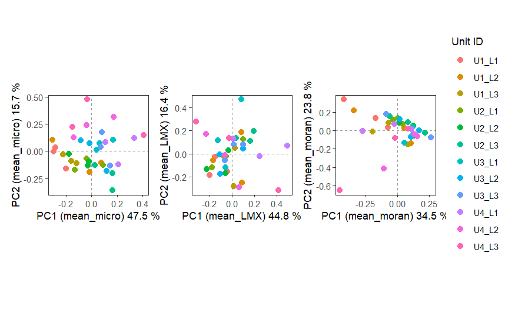

```r
p1 <- ggplot(PCA_scores_micro_mean,
       aes(x = PC1, y = PC2, color = factor(Unit_LineID))) +

  geom_hline(
    yintercept = 0,
    linetype = "dashed",
    color = "grey60",
    linewidth = 0.4
  ) +

  geom_vline(
    xintercept = 0,
    linetype = "dashed",
    color = "grey60",
    linewidth = 0.4
  ) +

  geom_point(
    size = 2.5
  ) +

  labs(  # 0.4746 0.1572
    x = "PC1 (mean_micro) 47.5 %",
    y = "PC2 (mean_micro) 15.7 %",
    color = "Unit ID"
  ) +

  theme_bw() +
  theme(
    aspect.ratio = 1.0,
    panel.grid = element_blank(),
    legend.position = "none"
  )

p2 <- ggplot(PCA_scores_LMX_mean,
       aes(x = PC1, y = PC2, color = factor(Unit_LineID))) +

  geom_hline(
    yintercept = 0,
    linetype = "dashed",
    color = "grey60",
    linewidth = 0.4
  ) +

  geom_vline(
    xintercept = 0,
    linetype = "dashed",
    color = "grey60",
    linewidth = 0.4
  ) +

  geom_point(
    size = 2.5
  ) +

  labs(  # 0.4485 0.1637
    x = "PC1 (mean_LMX) 44.8 %",
    y = "PC2 (mean_LMX) 16.4 %",
    color = "Unit ID"
  ) +

  theme_bw() +
  theme(
    aspect.ratio = 1.0,
    panel.grid = element_blank(),
    legend.position = "none"
  )

p3 <- ggplot(PCA_scores_moran_mean,
       aes(x = PC1, y = PC2, color = factor(Unit_LineID))) +

  geom_hline(
    yintercept = 0,
    linetype = "dashed",
    color = "grey60",
    linewidth = 0.4
  ) +

  geom_vline(
    xintercept = 0,
    linetype = "dashed",
    color = "grey60",
    linewidth = 0.4
  ) +

  geom_point(
    size = 2.5
  ) +

  labs(  # 0.3466 0.2376
    x = "PC1 (mean_moran) 34.5 %",
    y = "PC2 (mean_moran) 23.8 %",
    color = "Unit ID"
  ) +

  theme_bw() +
  theme(
    aspect.ratio = 1.0,
    panel.grid = element_blank()
  )

p1 + p2 + p3
```

#### [5.2.2] Functions for stratified PCA and model selection

##### Data setting and a simple function preparation

```r
## ========= USER EDIT =========
unit_col <- "Unit_LineID"  # unit identifier column (12 unique units)
response_col    <- c("LAI_2024", "LAI_2025", "root_weight", "penetrability")  # response column name

# exclude total_cover-based variables
micro_mean_cols <- colnames(micro_macro_P1_2024)[28:35] # include total cover
LMX_mean_cols <- colnames(micro_macro_P1_2024)[36:43] # include total cover
moran_mean_cols <- colnames(micro_macro_P1_2024)[44:51] # include total cover
print(micro_mean_cols)
```

```
[1] "mean_pillar"        "mean_exposedRoot"   "mean_LitterMax"
[4] "mean_soil_hardness" "mean_Litter_cover"  "mean_veg_cover"
[7] "mean_stone_cover"   "mean_total_cover"
```

```r
print(LMX_mean_cols)
```

```
[1] "LMX_mean_pillar"        "LMX_mean_exposedRoot"   "LMX_mean_LitterMax"
[4] "LMX_mean_soil_hardness" "LMX_mean_Litter_cover"  "LMX_mean_veg_cover"
[7] "LMX_mean_stone_cover"   "LMX_mean_total_cover"
```

```r
print(moran_mean_cols)
```

```
[1] "moran_mean_pillar"        "moran_mean_exposedRoot"
[3] "moran_mean_LitterMax"     "moran_mean_soil_hardness"
[5] "moran_mean_Litter_cover"  "moran_mean_veg_cover"
[7] "moran_mean_stone_cover"   "moran_mean_total_cover"
```

```r
## ============================

## --- keep only complete cases on used columns ---
use_cols <- c(unit_col, response_col, micro_mean_cols, LMX_mean_cols, moran_mean_cols)
micro_macro_P1_2024_v2 <- micro_macro_P1_2024[complete.cases(micro_macro_P1_2024[, use_cols]), use_cols, drop = FALSE]
print(micro_macro_P1_2024_v2)
```

|  | Unit_LineID | LAI_2024 | LAI_2025 | root_weight | penetrability | mean_pillar | mean_exposedRoot | mean_LitterMax | mean_soil_hardness | mean_Litter_cover | mean_veg_cover | mean_stone_cover | mean_total_cover | LMX_mean_pillar | LMX_mean_exposedRoot | LMX_mean_LitterMax | LMX_mean_soil_hardness | LMX_mean_Litter_cover | LMX_mean_veg_cover | LMX_mean_stone_cover | LMX_mean_total_cover | moran_mean_pillar | moran_mean_exposedRoot | moran_mean_LitterMax | moran_mean_soil_hardness | moran_mean_Litter_cover | moran_mean_veg_cover | moran_mean_stone_cover | moran_mean_total_cover |
| --- | --- | --- | --- | --- | --- | --- | --- | --- | --- | --- | --- | --- | --- | --- | --- | --- | --- | --- | --- | --- | --- | --- | --- | --- | --- | --- | --- | --- | --- |
| 7 | U1_L1 | 1.59 | 1.63 | 0.1700 | 5.623606 | 0.14285714 | 0.2857143 | 3.857143 | 7.571429 | 77.85714 | 2.857143 | 2.8571429 | 83.57143 | -2.35447670 | -1.00269548 | 3.47585933 | 0.182584918 | 1.25239411 | -1.639967140 | 0.27649941 | 1.2239225 | 0.669439261 | 0.8271797916 | 0.588250814 | 0.042019646 | 0.56796542 | 0.130034198 | 0.031379581 | 0.361623857 |
| 21 | U1_L1 | 1.52 | 1.51 | 0.0400 | 5.678285 | 0.07142857 | 0.5000000 | 3.642857 | 8.071429 | 81.07143 | 5.000000 | 0.3571429 | 86.42857 | -1.46088612 | -0.16152091 | 2.25342684 | 0.455228022 | 0.76366939 | -0.813157434 | -3.16508523 | 0.6874440 | 0.270938983 | 0.0211305205 | 0.211826009 | 0.140129284 | 0.42699340 | 0.015723384 | 0.198922840 | 0.266655222 |
| 35 | U1_L1 | 1.31 | 1.47 | 0.0060 | 7.440127 | 0.15384615 | 0.3846154 | 1.500000 | 6.769231 | 71.92308 | 6.538462 | 0.7692308 | 79.23077 | -0.81181090 | -0.99340588 | -3.66917611 | 0.005025219 | -0.28291297 | -0.386133719 | -1.01310484 | -0.2159084 | 0.218481869 | 0.7201760305 | 0.250900839 | 0.269078900 | 0.22351084 | 0.015294270 | 0.135229460 | 0.089383870 |
| 48 | U1_L2 | 1.70 | 2.14 | 0.5500 | 4.654823 | 0.07142857 | 0.5000000 | 3.742857 | 7.357143 | 85.00000 | 5.714286 | 3.2142857 | 93.92857 | -1.88199419 | -0.18183753 | 4.59665113 | 0.162452144 | 0.73945240 | -1.158107286 | -0.29097351 | 1.1296484 | 0.694115954 | 0.4240185529 | 0.360334955 | 0.166934674 | 0.72508243 | 0.082607486 | 0.014699553 | 0.587310961 |
| 62 | U1_L2 | 1.52 | 1.67 | 0.0600 | 10.240214 | 0.71428571 | 1.0000000 | 1.821429 | 6.000000 | 49.28571 | 11.071429 | 2.5000000 | 62.85714 | 1.43194034 | 2.18949811 | -0.57821212 | -1.339993603 | -0.38635970 | -0.056856392 | 0.13264908 | -0.4101643 | -0.075850447 | -0.0802559119 | 0.012509209 | 0.459063901 | 0.11876750 | 0.050020918 | 0.095605045 | 0.072980157 |
| 76 | U1_L2 | 1.23 | 1.45 | 0.0300 | 4.146808 | 0.69230769 | 0.5384615 | 1.346154 | 7.692308 | 60.00000 | 4.615385 | 4.2307692 | 68.84615 | 0.66630148 | -0.02430534 | -4.42039836 | 1.993880409 | -0.46522605 | -1.097791821 | 0.43544336 | -0.6166470 | -0.121492616 | 0.2794222872 | 0.238172077 | 0.212400361 | -0.03555768 | 0.086310067 | -0.007681695 | -0.113613402 |
| 89 | U1_L3 | 1.74 | 1.61 | 0.2600 | 5.000530 | 0.21428571 | 0.5000000 | 2.678571 | 5.000000 | 71.42857 | 8.571429 | 3.2142857 | 83.21429 | -0.93091771 | -0.07905984 | 0.78583129 | -1.015711618 | 0.32079949 | -0.420776368 | 0.77922919 | 0.3344070 | 0.487061340 | 0.3447718084 | 0.068228167 | 0.635402595 | 0.50385307 | 0.086944487 | 0.010150487 | 0.362706883 |
| 103 | U1_L3 | 1.26 | 1.72 | 0.5300 | 6.875920 | 0.42857143 | 0.7857143 | 1.892857 | 5.714286 | 72.50000 | 6.428571 | 1.7857143 | 80.71429 | 0.53246123 | 1.14611117 | -2.68983857 | -1.174614348 | 0.04849283 | -0.478663570 | -0.94312672 | -0.0978849 | -0.034020038 | -0.0530398678 | 0.063698462 | 0.500495035 | 0.10768350 | 0.108330387 | 0.111293046 | -0.024009611 |
| 117 | U1_L3 | 1.10 | 1.38 | 0.1100 | 5.244545 | 0.30769231 | 0.4615385 | 1.615385 | 8.307692 | 75.00000 | 6.153846 | 1.9230769 | 83.07692 | -0.48289244 | -0.25649098 | -4.91649663 | 1.579109471 | 0.58219440 | -1.128134968 | -0.12509662 | 0.1016456 | 0.163915549 | 0.3518548207 | 0.191203489 | 0.145011899 | 0.29279363 | 0.067850663 | 0.067556094 | 0.097041454 |
| 130 | U2_L1 | 1.61 | 1.49 | 0.1000 | 6.964329 | 0.14285714 | 0.6428571 | 2.714286 | 8.714286 | 50.00000 | 7.500000 | 3.9285714 | 61.42857 | -1.23298042 | 0.20585497 | 0.50175570 | 0.722630250 | -0.29595763 | 0.320079108 | -0.09978479 | 0.6681208 | 0.425477907 | 0.0484698140 | 0.029104193 | -0.018299474 | 0.12796825 | -0.006497573 | -0.028783108 | 0.327140499 |

[output cut: 26 more lines]

```r
## --- basic checks ---
units_list <- unique(micro_macro_P1_2024_v2[[unit_col]])
if (length(units_list) < 2) stop("Need >=2 unique units for unit-wise CV.")
message("N rows used: ", nrow(micro_macro_P1_2024_v2), " ; unique units: ", length(units_list))
```

```
N rows used: 36 ; unique units: 12
```

```r
rmse <- function(y, yhat) sqrt(mean((y - yhat)^2))
```

##### Fit PCA on training block and return scores for train data + projected scores for test data & extract PC scores

```r
pca_project_block <- function(X_train, X_test, s) {
  if (s == 0) return(list(train = NULL, test = NULL))
  fit <- rda(X_train, scale = TRUE)

  tr_sc <- scores(fit, display = "sites", choices = seq_len(s), scaling = 0)
  te_sc <- predict(fit, newdata = X_test, type = "wa")[, seq_len(s), drop = FALSE]

  list(train = as.matrix(tr_sc), test = as.matrix(te_sc), fit = fit)
}

## Build design matrices (PC scores) for a given (s_mu, s_L, s_M) within a fold
build_fold_design <- function(dat_train, dat_test, micro_cols, LMX_cols, moran_cols, s_mean, s_LMX, s_moran) {
  pcs_mean <- pca_project_block(dat_train[, micro_cols, drop = FALSE],
                              dat_test[, micro_cols, drop = FALSE], s_mean)
  pcs_LMX  <- pca_project_block(dat_train[, LMX_cols, drop = FALSE],
                              dat_test[, LMX_cols, drop = FALSE], s_LMX)
  pcs_moran  <- pca_project_block(dat_train[, moran_cols, drop = FALSE],
                              dat_test[, moran_cols, drop = FALSE], s_moran)

  Xtr <- cbind(pcs_mean$train, pcs_LMX$train, pcs_moran$train)
  Xte <- cbind(pcs_mean$test,  pcs_LMX$test,  pcs_moran$test)

  # If all s are 0: Xtr/Xte become NULL; handle later as intercept-only
  list(Xtr = Xtr, Xte = Xte)
}
```

##### OLS fit/predict setting and CV setting

```r
## OLS fit/predict for one fold
ols_fit_predict <- function(Xtr, ytr, Xte, n_test) {
  # Intercept-only
  if (is.null(Xtr) || ncol(Xtr) == 0) {
    return(rep(mean(ytr, na.rm = TRUE), n_test))
  }

  Xtr <- as.matrix(Xtr)
  Xte <- as.matrix(Xte)

  p <- ncol(Xtr)
  pc_names <- paste0("PC", seq_len(p))
  colnames(Xtr) <- pc_names
  colnames(Xte) <- pc_names

  df_tr <- as.data.frame(Xtr, check.names = FALSE)
  df_tr$y <- ytr

  df_te <- as.data.frame(Xte, check.names = FALSE)

  fml <- reformulate(pc_names, response = "y")
  fit <- lm(fml, data = df_tr)

  as.numeric(predict(fit, newdata = df_te))
}

## safer intercept-only predictor
predict_intercept_only <- function(ytr, n_test) rep(mean(ytr), n_test)

## Evaluate one model by leave-one-unit-out CV
cv_one_model <- function(dat, unit_column, y_column, micro_cols, LMX_cols, moran_cols, s_mean, s_LMX, s_moran) {
  units <- unique(dat[[unit_column]])
  fold_rmse <- numeric(length(units))
  names(fold_rmse) <- as.character(units)

  for (i in seq_along(units)) {
    u <- units[i]
    te_idx <- which(dat[[unit_column]] == u)
    tr_idx <- which(dat[[unit_column]] != u)

    dat_tr <- dat[tr_idx, , drop = FALSE]
    dat_te <- dat[te_idx, , drop = FALSE]

    des <- build_fold_design(dat_tr, dat_te, micro_cols, LMX_cols, moran_cols, s_mean, s_LMX, s_moran)
    yhat <- ols_fit_predict(des$Xtr, dat_tr[[y_column]], des$Xte, n_test = nrow(dat_te))

    fold_rmse[i] <- rmse(dat_te[[y_column]], yhat)
  }

  mean_rmse <- mean(fold_rmse)
  se_rmse   <- sd(fold_rmse) / sqrt(length(fold_rmse))

  list(fold_rmse = fold_rmse, mean_rmse = mean_rmse, se_rmse = se_rmse)
}


## Evaluate one model by leave-one-unit-out CV, for the specific unit of replication
cv_one_model_specific <- function(dat, test_unit, unit_column, y_column, micro_cols, LMX_cols, moran_cols, s_mean, s_LMX, s_moran) {
  units <- unique(dat[[unit_column]])

  te_idx <- which(dat[[unit_column]] == test_unit)
  tr_idx <- which(dat[[unit_column]] != test_unit)

  dat_tr <- dat[tr_idx, , drop = FALSE]
  dat_te <- dat[te_idx, , drop = FALSE]

  #dat_tr <- dat
  #dat_te <- dat

  des <- build_fold_design(dat_tr, dat_te, micro_cols, LMX_cols, moran_cols, s_mean, s_LMX, s_moran)
  yhat <- ols_fit_predict(des$Xtr, dat_tr[[y_column]], des$Xte, n_test = nrow(dat_te))
  return(yhat)
}
```

##### Compute AICc for a given model fit on FULL data (for reporting)

```r
## PCs are computed on full data per block.
aicc_full_fit <- function(dat, y_column, micro_cols, LMX_cols, moran_cols, s_mean, s_LMX, s_moran) {
  n <- nrow(dat)
  y <- dat[[y_column]]

  # build full PC scores
  make_full_scores <- function(cols, s) {
    if (s == 0) return(NULL)
    fit <- rda(dat[, cols, drop = FALSE], scale = TRUE)
    as.matrix(scores(fit, display = "sites", choices = seq_len(s), scaling = 0))
  }

  Z_micro <- make_full_scores(micro_cols, s_mean)
  Z_LMX <- make_full_scores(LMX_cols,  s_LMX)
  Z_moran <- make_full_scores(moran_cols,  s_moran)

  X <- cbind(Z_micro, Z_LMX, Z_moran)

  if (is.null(X) || ncol(X) == 0) {
    fit <- lm(y ~ 1)
  } else {
    colnames(X) <- paste0("PC", seq_len(ncol(X)))
    fit <- lm(y ~ ., data = data.frame(y = y, X))
  }

  k <- length(coef(fit)) # includes intercept
  aic <- AIC(fit)
  # AICc is defined only if (n - k - 1) > 0
  if ((n - k - 1) <= 0) return(NA_real_)
  aicc <- aic + (2 * k * (k + 1)) / (n - k - 1)
  aicc
}
```

##### Compute statistical significance for a given model fit on FULL data (for reporting)

```r
## PCs are computed on full data per block.
summary_full_fit <- function(dat, y_column, micro_cols, LMX_cols, moran_cols, s_mean, s_LMX, s_moran) {
  n <- nrow(dat)
  y <- dat[[y_column]]

  # build full PC scores
  make_full_scores <- function(cols, s) {
    if (s == 0) return(NULL)
    fit <- rda(dat[, cols, drop = FALSE], scale = TRUE)
    as.matrix(scores(fit, display = "sites", choices = seq_len(s), scaling = 0))
  }

  Z_micro <- make_full_scores(micro_cols, s_mean)
  Z_LMX <- make_full_scores(LMX_cols,  s_LMX)
  Z_moran <- make_full_scores(moran_cols,  s_moran)

  X <- cbind(Z_micro, Z_LMX, Z_moran)

  if (is.null(X) || ncol(X) == 0) {
    fit <- lm(y ~ 1)
  } else {
    colnames(X) <- paste0("PC", seq_len(ncol(X)))
    fit <- lm(y ~ ., data = data.frame(y = y, X))
  }

 summary(fit)
}
```